# Table of Contents (Jupyter)

• GITHUB LINK FOR EASY VIEWING OF .ipynb NOTEBOOK  
• 1.0 Understanding the Problem and the Data  
• About AdEase  
• Objective of this Exercise  
• 2.0 Import and Inspect the Data  
• Split the Page column to create more columns  
• 2.2 Statistical summary for numerical columns and Unique values for categorical data  
• 2.3 Adding insights about columns and data size.  
• 2.4 Data Dictionary  
• 2.5 Data Cleaning  
• 2.5.1 Check duplicate data  
• 2.6 Handling Missing Values  
• Lets investigate the missing data  
• 2.6.2 Imputation of Dates  
• 2.7 Creation of Helper functions  
• `ingesterCleanerImputerEngineer()`: Helper function for ingestion  
• `search_data()`: Extract rows from a DataFrame based on specified column-value conditions.  
• `readExoData()` : Helper function to read exogeneous data  
• `addExogeneousColumnToADataFrame()`  
• `extractRowTransposeColumn()` : Select row, transpose  
• `plot_data_staggered()` :Creates a staggered plot for click counts of multiple pages with optional campaign indicators.  
• `prepare_time_series()`  
• `dataSegmenter()`  
• `addModelAttempt()`-Adds results from trying a model on a data  
• `getModelHistory()`  
• `getAllBestModels()`  
• `getAttemptsSummaryTable()`  
• `printModelDictSummary()`  
• `printModelDictSummaryDETAILED()`  
• 3.0 Explore Data Characteristics  
• 3.1 Univariate Analysis (Analysis of one attribute at a time.)  
• univariate_ordinal_analysis  
• page_title  
• access_type  
• access_origin  
• language  
• domain  
• 3.2 Bivariate Analysis  
• Helper function to plot all categories  
• ClickCount and access_type  
• ClickCount and access_origin  
• ClickCount and language  
• Do EN pages cluster differently from FR pages in level/variance/seasonality/autocorrelation (things SARIMAX cares about)?  
• ClickCount and domain  
• annotate_bars  
• access_origin and access_type  
• language and access_origin  
• language and access_type  
• language and domain  
• access_type and domain  
• Multivariate Analysis  
• Language, access_origin, access_type and clickCount  
• Segmentation logic  
• **Brief Summary of Multi-Series Forecasting Options**  
• 4.0 Modeling  
• 4.1 Pipeline Flow Design  
• Take a sample data and analyse  
• Stationarity check (ADF test)  
• ACF PACF  
• Setting up Train Test sets for model performance evaluation  
• Train Test Split  
• Fitting ARIMA Model -------------------------------------  
• Fit on One series first and do a Performance Review  
• Define the ARIMA search space  
• Grid‑search function (MAPE + AIC + BIC)  
• gridSearchARIMAAllSegments()  
• Checking for Seasonality  
• Plot Seasonal decomposition of one sample  
• **ADF stationarity ≠ “no trend or no seasonality”**  
• Determining Seasonality length  
• Business-level interpretation  
• Plot Seasonal Decomposition for all Segments  
• ACF and PACF for seasonally differenced data  
• Fitting SARIMA model -------------------------------------  
• Fitting SARIMAX model ---------------------------------  
• Buiding Exogeneous column for each segment  
• Visual examination of Exogeneous Variable impact on Time Series  
• Running gridSearchSARIMAXAllSegments  
• Fitting Prophet --------------------------------------  
• Prophet helper functions  
• `fitProphetWithRegressors()`  
• `gridSearchProphetWithRegressors()`  
• `gridSearchProphetAllSegments()`  
• printModelDictSummaryDETAILED  
• Final Model Creation  
• `extract_best_models() fit_sarimax_full() fit_prophet_full`  
• `plot_full_actual_vs_predicted()`  
• `run_pipeline()`  
• RUN THE PIPELINE  
• SAVE MODELS  
• 6. Actionable Insights & Recommendations  
• 6.1 Summary of Observations from EDA  
• 6.2 Insights from EDA  
• 6.4 Insights from Model Results  
• 6.5 🧭 **Recommendations**  
• 6.6 Questionnaire:

| These are insights got from analysing the data, in Pink color |
| --- |
| ''' ''' code sections are notes to self, some quick code snippets, or some notes while doing analysis |

## GITHUB LINK FOR EASY VIEWING OF .ipynb NOTEBOOK

**Please note, when converting to PDF, the links in TOC stop working. You may like to see the original report's .ipynb file. Please see it on my Github Repository here **

- HTML Page
  - https://github.com/amitguptaforwork/dataanalytics_portfolio_projects/blob/main/CaseStudyAdEase_TimeSeriesSARIMAXProphet/AdEase_AmitG.html
- JupyterNotebook
  - https://github.com/amitguptaforwork/dataanalytics_portfolio_projects/blob/main/CaseStudyAdEase_TimeSeriesSARIMAXProphet/AdEaser_AmitG.ipynb

# 1.0 Understanding the Problem and the Data

## About AdEase

Ad Ease is an ads and marketing based company helping businesses elicit maximum clicks @ minimum cost. They provide ad infrastructure to help businesses promote themselves easily, effectively, and economically. The interplay of 3 AI modules - Design, Dispense, and Decipher, come together to make it this an end-to-end 3 step process digital advertising solution for all.

## Objective of this Exercise

The **objective of this problem** is to use historical Wikipedia page-view data to **forecast future traffic**

- We have page view data for each page
- User is interested in placing an ad based on a language or region. They want to know how their ads will perform on pages in different languages.
- Thus the goal of the case study is to predict the page view per segment (segment could be language or language + some more criteria, which will be determined during the course of the study)
- Final aim of user is to answer this question
  - **If I place my ad on French pages, how many page views can I expect**,
  - **If I place my ad on English pages, how many page views can I expect**

# 2.0 Import and Inspect the Data

```python
import pandas as pd
import matplotlib.pyplot as plt
import seaborn as sns
import numpy as np

# plt.rcParams['figure.figsize'] = (20, 8) sets a global default figure size for all Matplotlib plots in the current Python session.
# rcParams = runtime configuration parameters for Matplotlib
plt.rcParams['figure.figsize'] = (20,8)
```

```python
'''
Notes to Self
During this step, looking into the statistics is critical to gain initial know-how of its structure, variable kinds, and capability issues.

'''
```

```
' \nNotes to Self\nDuring this step, looking into the statistics is critical to gain initial know-how of its structure, variable kinds, and capability issues.\n\n'
```

```python
df =pd.read_csv("train_1.csv", encoding="utf-8") # we need to use utf-8 as we have data not just in English but other languages like Russian
df.columns
```

```
Index(['Page', '2015-07-01', '2015-07-02', '2015-07-03', '2015-07-04',
       '2015-07-05', '2015-07-06', '2015-07-07', '2015-07-08', '2015-07-09',
       ...
       '2016-12-22', '2016-12-23', '2016-12-24', '2016-12-25', '2016-12-26',
       '2016-12-27', '2016-12-28', '2016-12-29', '2016-12-30', '2016-12-31'],
      dtype='object', length=551)
```

## Split the Page column to create more columns

```python
df[['page_title', 'lang_domain', 'access_type', 'access_origin']] = \
    df['Page'].str.rsplit('_', n=3, expand=True)

df[['language', 'domain']] = \
    df['lang_domain'].str.split('.', n=1, expand=True)

df.drop(columns='lang_domain', inplace=True)

df.head()
```

|  | Page | 2015-07-01 | 2015-07-02 | 2015-07-03 | 2015-07-04 | 2015-07-05 | 2015-07-06 | 2015-07-07 | 2015-07-08 | 2015-07-09 | ... | 2016-12-27 | 2016-12-28 | 2016-12-29 | 2016-12-30 | 2016-12-31 | page_title | access_type | access_origin | language | domain |
| --- | --- | --- | --- | --- | --- | --- | --- | --- | --- | --- | --- | --- | --- | --- | --- | --- | --- | --- | --- | --- | --- |
| 0 | 2NE1_zh.wikipedia.org_all-access_spider | 18.0 | 11.0 | 5.0 | 13.0 | 14.0 | 9.0 | 9.0 | 22.0 | 26.0 | ... | 20.0 | 22.0 | 19.0 | 18.0 | 20.0 | 2NE1 | all-access | spider | zh | wikipedia.org |
| 1 | 2PM_zh.wikipedia.org_all-access_spider | 11.0 | 14.0 | 15.0 | 18.0 | 11.0 | 13.0 | 22.0 | 11.0 | 10.0 | ... | 30.0 | 52.0 | 45.0 | 26.0 | 20.0 | 2PM | all-access | spider | zh | wikipedia.org |
| 2 | 3C_zh.wikipedia.org_all-access_spider | 1.0 | 0.0 | 1.0 | 1.0 | 0.0 | 4.0 | 0.0 | 3.0 | 4.0 | ... | 4.0 | 6.0 | 3.0 | 4.0 | 17.0 | 3C | all-access | spider | zh | wikipedia.org |
| 3 | 4minute_zh.wikipedia.org_all-access_spider | 35.0 | 13.0 | 10.0 | 94.0 | 4.0 | 26.0 | 14.0 | 9.0 | 11.0 | ... | 11.0 | 17.0 | 19.0 | 10.0 | 11.0 | 4minute | all-access | spider | zh | wikipedia.org |
| 4 | 52_Hz_I_Love_You_zh.wikipedia.org_all-access_s... | NaN | NaN | NaN | NaN | NaN | NaN | NaN | NaN | NaN | ... | 11.0 | 27.0 | 13.0 | 36.0 | 10.0 | 52_Hz_I_Love_You | all-access | spider | zh | wikipedia.org |

5 rows × 556 columns

## 2.2 Statistical summary for numerical columns and Unique values for categorical data

- Instead of manually creating tables and collecting values lets automate the table creation
- We will generate a table of all columns in Markdown format
- We will paste this table into a markdown cell and then we may add additional analysis

```python
#!pip install tabulate
from tabulate import tabulate
def generate_markdown_table_with_details(df):
    column_details = []
    for col in df.columns:
        dtype = str(df[col].dtype)

        if dtype == 'object' or dtype=='category':
            cat_or_num = 'Categorical'
            details = df[col].unique().tolist()
            if(len(details)>10):
                details= f'{df[col].nunique()} unique values.Ex.{",".join([str(x) for x in details[:3]])}'

        else:
            cat_or_num = 'Numerical'
            details = f"Min: {df[col].min()}, Max: {df[col].max()}"
        column_details.append([col, dtype, cat_or_num, details, ''])

    # Create a DataFrame for the table
    table_df = pd.DataFrame(column_details, columns=['Column Name', 'Data Type', 'Categorical or Numerical', 'Details', 'Business Description(fill manually)'])

    # Convert DataFrame to Markdown
    markdown_table = tabulate(table_df, headers='keys', tablefmt='pipe', showindex=False)
    return markdown_table

markdown_table = generate_markdown_table_with_details(df)
print(f'There are a total of {df.shape[0]:,} rows and {df.shape[1]} columns')
print(markdown_table)
```

## 2.3 Adding insights about columns and data size.

- We will copy the markdown table generated above and add our inputs by analysing the columns.
- We identify which columns are numerical, which are categorical
- Within categorical, we identify if it is nominal or ordinal data. This helps us to decide best graph to use
- Also ordinal data can be converted into numeric using codes thereby making it available for some kind of graphs.

## 2.4 Data Dictionary

There are a total of 145,063 rows and 556 columns

| Column Name | Data Type | Categorical or Numerical | Details | Business Description(filled manually) |
| --- | --- | --- | --- | --- |
| Page | object | Categorical | 145063 unique values.Ex.2NE1_zh.wikipedia.org_all-access_spider, | Name of page along with other metadata like domain, language, access_type , access_origin |
| Date (550 Columns) | float64 | Numerical | Min: 2015-07-01, Max: 2016-12-31 | Click count from 550 consecutive days for each page |
| page_title | object | Categorical | 49174 unique values.Ex.2NE1,2PM,3C | Page name |
| access_type | object | Categorical | ['all-access', 'desktop', 'mobile-web'] | How the content is accessed - all-access → aggregated access (desktop + mobile + others), desktop → desktop browsers only, mobile-web → mobile browsers (not apps) |
| access_origin | object | Categorical | ['spider', 'all-agents'] | Who is making the request - all-agents → normal users and bots combined , spider → automated crawlers (search engine bots like Googlebot, Bingbot ) |
| language | object | Categorical | ['zh', 'fr', 'en', 'commons', 'ru', 'www', 'de', 'ja', 'es'] | Language |
| domain | object | Categorical | ['wikipedia.org', 'wikimedia.org', 'mediawiki.org'] | wikipedia.org → article text, wikimedia/commons → images, audio, video & media catalogues, mediawiki.org → software resources such as JavaScript, CSS, system messages, and technical documentation. |

## 2.5 Data Cleaning

We can check for duplicate data

### 2.5.1 Check duplicate data

```python
#Lets check if we have duplicates.
df_duplicate  = df[df.duplicated(keep=False)].sort_values(by='Page')
print(f'We have {len(df_duplicate)*100/len(df)}% duplicate rows')
df_duplicate
```

```
We have 0.0% duplicate rows
```

|  | Page | 2015-07-01 | 2015-07-02 | 2015-07-03 | 2015-07-04 | 2015-07-05 | 2015-07-06 | 2015-07-07 | 2015-07-08 | 2015-07-09 | ... | 2016-12-27 | 2016-12-28 | 2016-12-29 | 2016-12-30 | 2016-12-31 | page_title | access_type | access_origin | language | domain |
| --- | --- | --- | --- | --- | --- | --- | --- | --- | --- | --- | --- | --- | --- | --- | --- | --- | --- | --- | --- | --- | --- |

0 rows × 556 columns

## 2.6 Handling Missing Values

Now let's check if there are any missing values in our dataset or not.

```python
'''
Notes to Self
Missing Data can also refer to as NA(Not Available) values in pandas. There are several useful functions for detecting, removing, and replacing null values in Pandas DataFrame :

isnull()
notnull()
dropna()
fillna()
replace()
interpolate()
'''
```

```
' \nNotes to Self\nMissing Data can also refer to as NA(Not Available) values in pandas. There are several useful functions for detecting, removing, and replacing null values in Pandas DataFrame :\n\nisnull()\nnotnull()\ndropna()\nfillna()\nreplace()\ninterpolate()\n'
```

- Lets check if we have ALL dates, no dates are missing
- We will use column[1] and column[-6], the first and last date columns and
  - count how many days are there between them.
  - It should be same as the number of date columns.

```python
print(f'We expected {(pd.to_datetime(df.columns[-6])- pd.to_datetime(df.columns[1])).days+1} date columns which is same as the given number of date columns.')
```

```
We expected 550 date columns which is same as the given number of date columns.
```

```python
# sns.heatmap(df.isnull())
```

[figure not shown]

The absense of vertical lines shows that there is no date where data from all pages is missing

Continuous horizontal line means data is continuously missing. This may indicate that the page was created after that date. This missing data is actually MNAR - missing not at random. Because we know the reason why its missing.

Broken lines means data is missing in-between. This is genuine case of missing data and its MCAR- Missing completely at Random or MAR - missing at random.

### Lets investigate the missing data

```python
#Create a new column in the dataframe that counts how many missing values are there in that row
df['NumberOfMissingValues'] = pd.DataFrame(df.isnull().sum(axis=1))
```

```python
totalRows = len(df)
print("Total rows = ",totalRows)
lenNoMissing = len(df.loc[df.NumberOfMissingValues==0])
print(f"Rows with no missing data for 550 days={lenNoMissing} ({round(lenNoMissing*100/totalRows,1)}%)")
lenSomeMissing = len(df.loc[df.NumberOfMissingValues>0])
print(f"Rows with atlease one missing data={lenSomeMissing} ({round(lenSomeMissing*100/totalRows,1)}%)")

lenAllMissing = len(df.loc[df.NumberOfMissingValues==550])
print(f"Rows with ALL 550 days missing data={lenAllMissing} ({round(lenAllMissing*100/totalRows,1)}%)")
```

```
Total rows =  145063
Rows with no missing data for 550 days=117277 (80.8%)
Rows with atlease one missing data=27786 (19.2%)
Rows with ALL 550 days missing data=652 (0.4%)
```

Rows with no missing data for 550 days=117277 (80.8%)

Rows with ALL 550 days missing data=652 (0.4%)- These rows can be dropped

Drop rows that have all 550 dates' data missing

```python
df.drop(df.loc[df.NumberOfMissingValues==550].index, inplace=True)
len(df)
```

```
144411
```

From 1,45,063, 652 rows were dropped, and now we have 1,44,411 rows

### 2.6.2 Imputation of Dates

We have missing data on a row basis. So we will do this

**Rule**

- For each row:
  - Traverse left → right
  - Leading NaNs (before first valid value) → fill with 0
  - After first valid value → interpolate missing values

```python
df.head()
```

|  | Page | 2015-07-01 | 2015-07-02 | 2015-07-03 | 2015-07-04 | 2015-07-05 | 2015-07-06 | 2015-07-07 | 2015-07-08 | 2015-07-09 | ... | 2016-12-28 | 2016-12-29 | 2016-12-30 | 2016-12-31 | page_title | access_type | access_origin | language | domain | NumberOfMissingValues |
| --- | --- | --- | --- | --- | --- | --- | --- | --- | --- | --- | --- | --- | --- | --- | --- | --- | --- | --- | --- | --- | --- |
| 0 | 2NE1_zh.wikipedia.org_all-access_spider | 18.0 | 11.0 | 5.0 | 13.0 | 14.0 | 9.0 | 9.0 | 22.0 | 26.0 | ... | 22.0 | 19.0 | 18.0 | 20.0 | 2NE1 | all-access | spider | zh | wikipedia.org | 0 |
| 1 | 2PM_zh.wikipedia.org_all-access_spider | 11.0 | 14.0 | 15.0 | 18.0 | 11.0 | 13.0 | 22.0 | 11.0 | 10.0 | ... | 52.0 | 45.0 | 26.0 | 20.0 | 2PM | all-access | spider | zh | wikipedia.org | 0 |
| 2 | 3C_zh.wikipedia.org_all-access_spider | 1.0 | 0.0 | 1.0 | 1.0 | 0.0 | 4.0 | 0.0 | 3.0 | 4.0 | ... | 6.0 | 3.0 | 4.0 | 17.0 | 3C | all-access | spider | zh | wikipedia.org | 0 |
| 3 | 4minute_zh.wikipedia.org_all-access_spider | 35.0 | 13.0 | 10.0 | 94.0 | 4.0 | 26.0 | 14.0 | 9.0 | 11.0 | ... | 17.0 | 19.0 | 10.0 | 11.0 | 4minute | all-access | spider | zh | wikipedia.org | 0 |
| 4 | 52_Hz_I_Love_You_zh.wikipedia.org_all-access_s... | NaN | NaN | NaN | NaN | NaN | NaN | NaN | NaN | NaN | ... | 27.0 | 13.0 | 36.0 | 10.0 | 52_Hz_I_Love_You | all-access | spider | zh | wikipedia.org | 291 |

5 rows × 557 columns

```python
df.drop(columns=['NumberOfMissingValues'],inplace=True)
```

```python
def processRowNans(row):
    row = row.copy()
    first_valid_idx = row.first_valid_index()

    if first_valid_idx is None:
        return row.fillna(0)

    row.loc[:first_valid_idx] = row.loc[:first_valid_idx].fillna(0)
    row.loc[first_valid_idx:] = row.loc[first_valid_idx:].interpolate(
        method='linear',
        limit_direction='forward'
    )

    return row

cat_cols = df.select_dtypes(include='object').columns
num_cols = df.select_dtypes(exclude='object').columns

df[num_cols] = df[num_cols].apply(processRowNans, axis=1)
```

Lets check if any nulls now.

```python
# PerformanceWarning: DataFrame is highly fragmented. This is usually the result of calling frame.insert many times,
# which has poor performance. Consider joining all columns at once using pd.concat(axis=1) instead.
# To get a de-fragmented frame, use newframe = frame.copy()
df = df.copy()


df['NumberOfMissingValues'] = pd.DataFrame(df.isnull().sum(axis=1))
totalRows = len(df)
print("Total rows = ",totalRows)
lenNoMissing = len(df.loc[df.NumberOfMissingValues==0])
print(f"Rows with no missing data for 550 days={lenNoMissing} ({round(lenNoMissing*100/totalRows,1)}%)")
```

```
Total rows =  144411
Rows with no missing data for 550 days=144411 (100.0%)
```

Total rows = 144411

Rows with no missing data for 550 days=144411 (100.0%)

```python
df.drop(columns=['NumberOfMissingValues'],inplace=True)
```

## 2.7 Creation of Helper functions

- The analysis we did above will be put in function form so that we can process data in a pipeline.

### `ingesterCleanerImputerEngineer()`: Helper function for ingestion

1. Function will read a CSV
2. Split Page into columns
3. Drop empty rows
4. Impute null values in rows that have some data
5. Return dataframe

```python
def ingesterCleanerImputerEngineer(filepath):
    l_df =pd.read_csv(filepath)

    #Split the Page column to create more columns
    l_df[['page_title', 'lang_domain', 'access_type', 'access_origin']] = \
    l_df['Page'].str.rsplit('_', n=3, expand=True)

    l_df[['language', 'domain']] = \
        l_df['lang_domain'].str.split('.', n=1, expand=True)

    l_df.drop(columns='lang_domain', inplace=True)

    # Lets investigate the missing data
    #Create a new column in the dataframe that counts how many missing values are there in that row
    l_df['NumberOfMissingValues'] = pd.DataFrame(df.isnull().sum(axis=1))
    totalRows = len(l_df)
    print("Total rows = ",totalRows)
    lenNoMissing = len(l_df.loc[l_df.NumberOfMissingValues==0])
    print(f"Rows with no missing data for 550 days={lenNoMissing} ({round(lenNoMissing*100/totalRows,1)}%)")
    lenSomeMissing = len(l_df.loc[l_df.NumberOfMissingValues>0])
    print(f"Rows with atlease one missing data={lenSomeMissing} ({round(lenSomeMissing*100/totalRows,1)}%)")

    lenAllMissing = len(l_df.loc[l_df.NumberOfMissingValues==550])
    print(f"Rows with ALL 550 days missing data={lenAllMissing} ({round(lenAllMissing*100/totalRows,1)}%)")

    # Drop rows that have all 550 dates' data missing
    l_df.drop(l_df.loc[l_df.NumberOfMissingValues==550].index, inplace=True)
    print('After dropping empty rows',len(l_df))
    l_df.drop(columns=['NumberOfMissingValues'],inplace=True)


    # Imputation of Dates
        #   We have missing data on a row basis.  So we will do this

        # **Rule**
        # - For each row:
        # - Traverse left → right
        # - Leading NaNs (before first valid value) → fill with 0
        # - After first valid value → interpolate missing values
    print("Now imputing missing data...pl wait for sometime")
    cat_cols = l_df.select_dtypes(include='object').columns
    num_cols = l_df.select_dtypes(exclude='object').columns

    l_df[num_cols] = l_df[num_cols].apply(processRowNans, axis=1)
    l_df = l_df.copy()
    print("Imputation completed.")
    return l_df

df_with_extra_columns= ingesterCleanerImputerEngineer("train_1.csv")
df_with_extra_columns.head()
```

```
Total rows =  145063
Rows with no missing data for 550 days=144411 (99.6%)
Rows with atlease one missing data=0 (0.0%)
Rows with ALL 550 days missing data=0 (0.0%)
After dropping empty rows 145063
Now imputing missing data...pl wait for sometime
Imputation completed.
```

|  | Page | 2015-07-01 | 2015-07-02 | 2015-07-03 | 2015-07-04 | 2015-07-05 | 2015-07-06 | 2015-07-07 | 2015-07-08 | 2015-07-09 | ... | 2016-12-27 | 2016-12-28 | 2016-12-29 | 2016-12-30 | 2016-12-31 | page_title | access_type | access_origin | language | domain |
| --- | --- | --- | --- | --- | --- | --- | --- | --- | --- | --- | --- | --- | --- | --- | --- | --- | --- | --- | --- | --- | --- |
| 0 | 2NE1_zh.wikipedia.org_all-access_spider | 18.0 | 11.0 | 5.0 | 13.0 | 14.0 | 9.0 | 9.0 | 22.0 | 26.0 | ... | 20.0 | 22.0 | 19.0 | 18.0 | 20.0 | 2NE1 | all-access | spider | zh | wikipedia.org |
| 1 | 2PM_zh.wikipedia.org_all-access_spider | 11.0 | 14.0 | 15.0 | 18.0 | 11.0 | 13.0 | 22.0 | 11.0 | 10.0 | ... | 30.0 | 52.0 | 45.0 | 26.0 | 20.0 | 2PM | all-access | spider | zh | wikipedia.org |
| 2 | 3C_zh.wikipedia.org_all-access_spider | 1.0 | 0.0 | 1.0 | 1.0 | 0.0 | 4.0 | 0.0 | 3.0 | 4.0 | ... | 4.0 | 6.0 | 3.0 | 4.0 | 17.0 | 3C | all-access | spider | zh | wikipedia.org |
| 3 | 4minute_zh.wikipedia.org_all-access_spider | 35.0 | 13.0 | 10.0 | 94.0 | 4.0 | 26.0 | 14.0 | 9.0 | 11.0 | ... | 11.0 | 17.0 | 19.0 | 10.0 | 11.0 | 4minute | all-access | spider | zh | wikipedia.org |
| 4 | 52_Hz_I_Love_You_zh.wikipedia.org_all-access_s... | 0.0 | 0.0 | 0.0 | 0.0 | 0.0 | 0.0 | 0.0 | 0.0 | 0.0 | ... | 11.0 | 27.0 | 13.0 | 36.0 | 10.0 | 52_Hz_I_Love_You | all-access | spider | zh | wikipedia.org |

5 rows × 556 columns

### `search_data()`: Extract rows from a DataFrame based on specified column-value conditions.

- This will help us to select rows, say we want to select all rows with pages in English, or all English rows not accessed via spider
- This function supports passing any number of search criteria by way of **kwargs
- It also provides flexibility to select some random rows or all rows.
  - This is useful because we use this function sometimes to just sample some rows matching a criteria and plotting them (used during EDA)
  - And sometimes to select ALL rows matching a criteria (we use this to select data for our various segments later in the study)

```python
#Only one search criteria
def search_dataV1(sampleSize=10, colName=None, colValue=None ):
    if colName is not None:
        msg = f"{sampleSize} random rows where {colName} == {colValue}"
        selectedRows = df_with_extra_columns.loc[df_with_extra_columns[colName]==colValue].sample(sampleSize)
    else:
        msg =f"{sampleSize} random rows from entire data"
        selectedRows = df_with_extra_columns.sample(sampleSize)
    print(f"Extracting ",msg)
    return selectedRows,msg

# More flexible version.  This support infinite search conditions (all equalities though, no negation)
def search_data(sampleSize=10, **kwargs):
    """
    Extract random rows from a DataFrame based on specified column-value conditions.

    Parameters:
    -----------
    sampleSize : int, optional
        The number of random rows to return. Default is 10.
        -1 = All rows

    **kwargs : keyword arguments
        Multiple pairs of column names and their corresponding values to filter the DataFrame.
        Each column name should be prefixed with 'colName' followed by an index (e.g., 'colName1').
        The corresponding values should be provided as 'val' followed by the same index (e.g., 'val1').

        For example:
        - colName1='column_a' and val1=5 will filter rows where column_a equals 5.
        - You can specify multiple conditions:
          - colName1='column_a', val1=5, colName2='column_b', val2=10

    Returns:
    --------
    selectedRows : DataFrame
        A random sample of rows that meet the specified conditions.

    msg : str
        A message indicating the filtering criteria used for extraction.

    Example:
    --------
    # Suppose df_with_extra_columns is your DataFrame.
    selected_data, message = search_data(10, colName1='age', val1=30, colName2='city', val2='New York')

    This would return 10 random rows from `df_with_extra_columns` where 'age' is 30 and 'city' is 'New York'.

    Notes:
    ------
    - If no column-value pairs are provided in `kwargs`, the function will return a random sample from the entire DataFrame.
    - Ensure that the DataFrame is named `df_with_extra_columns` before calling this function.

    """
    if(sampleSize==-1):
        sampleSizeStr="All"
    else:
        sampleSizeStr=f'random'
    # Initialize the query string and parameters dictionary
    query_conditions = []
    titleDict={}
    # Loop through the kwargs to create conditions for the query
    for key, value in kwargs.items():
        # print(key,value)
        if key.startswith('colName') and value is not None:
            # Get the corresponding val parameter
            col_index = key[-1]  # Extract the index (1, 2, ...) from 'colName1', 'colName2', ...
            val_key = f'val{col_index}'
            col_value = kwargs.get(val_key)
            # print(value,col_value)
            if col_value is not None:
                # Add to the query conditions
                query_conditions.append(f"({value} == '{col_value}')")  # Using @ to reference variable in `query`
                titleDict[value]=col_value
                # print("added======",titleDict)

    # Construct the final query string

    if query_conditions:
        query_string = ' & '.join(query_conditions)
        # print(query_string)
        if(sampleSize!=-1):
            selectedRows = df_with_extra_columns.query(query_string).sample(sampleSize)
        else:
            selectedRows = df_with_extra_columns.query(query_string)
        msg = f"{sampleSizeStr} {len(selectedRows)} rows where " + ' and '.join(f"{key} == {val}" for key, val in titleDict.items())
    else:
        if(sampleSize!=-1):
            selectedRows = df_with_extra_columns.sample(sampleSize)
        else:
            selectedRows = df_with_extra_columns
        msg = f"{sampleSizeStr} {len(selectedRows)} rows from entire data"

    print(f"search_data():Searched", msg)
    return selectedRows, msg

#Trial run to see how the data looks like.
rows,title=search_data(5,
                       colName1='language',val1='www',
                       colName2='access_origin',va12='spider',
                       colName3='access_type',val3='desktop')
rows
```

```
search_data():Searched random 5 rows where language == www and access_type == desktop
```

|  | Page | 2015-07-01 | 2015-07-02 | 2015-07-03 | 2015-07-04 | 2015-07-05 | 2015-07-06 | 2015-07-07 | 2015-07-08 | 2015-07-09 | ... | 2016-12-27 | 2016-12-28 | 2016-12-29 | 2016-12-30 | 2016-12-31 | page_title | access_type | access_origin | language | domain |
| --- | --- | --- | --- | --- | --- | --- | --- | --- | --- | --- | --- | --- | --- | --- | --- | --- | --- | --- | --- | --- | --- |
| 43712 | Special:WhatLinksHere/Help:Categories/ja_www.m... | 1.0 | 1.0 | 1.0 | 1.0 | 1.0 | 1.0 | 1.125 | 1.25 | 1.375 | ... | 1.0 | 1.0 | 1.0 | 1.0 | 1.0 | Special:WhatLinksHere/Help:Categories/ja | desktop | all-agents | www | mediawiki.org |
| 42464 | How_to_contribute/an_www.mediawiki.org_desktop... | 33.0 | 40.0 | 63.0 | 87.0 | 70.0 | 72.0 | 58.000 | 76.00 | 42.000 | ... | 48.0 | 226.0 | 50.0 | 77.0 | 74.0 | How_to_contribute/an | desktop | all-agents | www | mediawiki.org |
| 43494 | MediaWiki:Gadget-UTCLiveClock.js_www.mediawiki... | 1.0 | 6.0 | 4.0 | 2.0 | 7.0 | 4.0 | 15.000 | 3.00 | 2.000 | ... | 6.0 | 9.0 | 5.0 | 3.0 | 1.0 | MediaWiki:Gadget-UTCLiveClock.js | desktop | all-agents | www | mediawiki.org |
| 43010 | API:Protect_www.mediawiki.org_desktop_all-agents | 15.0 | 28.0 | 15.0 | 15.0 | 15.0 | 27.0 | 24.000 | 22.00 | 18.000 | ... | 18.0 | 11.0 | 10.0 | 24.0 | 20.0 | API:Protect | desktop | all-agents | www | mediawiki.org |
| 43739 | Topic:Szhapu3bcbotvq3l_www.mediawiki.org_deskt... | 0.0 | 0.0 | 0.0 | 0.0 | 0.0 | 0.0 | 0.000 | 0.00 | 0.000 | ... | 2.0 | 2.0 | 2.0 | 2.0 | 2.0 | Topic:Szhapu3bcbotvq3l | desktop | all-agents | www | mediawiki.org |

5 rows × 556 columns

### `readExoData()` : Helper function to read exogeneous data

```python
def readExoData(filepath):
    print(f"readExoData():Reading {filepath}")
    return pd.Series(pd.read_csv(filepath, header='infer').iloc[:, 0].values)
exog_campaign_series = readExoData("Exog_Campaign_eng")
```

```
readExoData():Reading Exog_Campaign_eng
```

```python
len(exog_campaign_series.values)
```

```
550
```

### `addExogeneousColumnToADataFrame()`

We pass a dataframe and a series containing exogeneous column's data, it returns a new dataframe with exogeneous column added to the dataframe

```python
def addExogeneousColumnToADataFrame(data, exogSeries,exogSeriesName):
        print("addExogeneousColumnToADataFrame():Adding the exogeneous variable (campaign data) as a column")
        new_df = data.copy()
        # This is the fastest method
        #     No index alignment => .values avoids expensive index matching =>
        #     Pure NumPy assignment => Pandas internally performs a vectorized copy
        #     Memory layout is contiguous → cache-friendly
        #     O(n) operation
        new_df[exogSeriesName] = exogSeries.values
        return new_df
```

### `extractRowTransposeColumn()` : Select row, transpose

Helper function to convert one seleted row into a transposed dataframe

```python
# rowIndexToExtract=-1 means extract all rows from given dataframe
def extractRowTransposeColumn(wide_data_with_extra_columns = df_with_extra_columns, rowIndexToExtract=-1,**kwargs):
    # rowIndexToExtract=-1 means extract all rows from given dataframe
    datasetName = kwargs.get("modelName","given dataframe")
    if rowIndexToExtract!=-1:
        #0th column is Page
        #Last 5 columns are strings, that were created as part of analysis.
        #We want to remove these columns and get only the date columns
        #We also transpose the data so that dates come in rows.
        print(f"extractRowTransposeColumn():Transposing row {rowIndexToExtract} from {datasetName}")
        row_df = wide_data_with_extra_columns.iloc[rowIndexToExtract, 1:-5].T.to_frame()
        row_df.columns=['clickCount'] #we rename the column
    else:
        print(f"extractRowTransposeColumn():Transposing ALL rows from {datasetName} that has {len(wide_data_with_extra_columns)} rows")
        row_df = wide_data_with_extra_columns.iloc[:, 1:-5].T

    #To suppress SARIMAX error- ValueError: Pandas data cast to numpy dtype of object
    #The clickCount data is read as an object.  SARIMAX needs it as a int
    #Using apply makes it possible to work on multiple columns if available.
    row_df = row_df.apply(pd.to_numeric, errors="coerce")

    #To suppress SARIMAX warning - ValueWarning: No frequency information was provided, so inferred frequency D will be used.
    #This avoids NaNs but only works if there are no missing days.  As we have already ensured that in this project,
    #so we can use this approach.
    #Setting .index.freq does nothing unless the index is first converted to a DatetimeIndex.
    #The transpose got us the dates as index, but pandas still does not consider it DatetimeIndex
    row_df.index = pd.to_datetime(row_df.index)
    row_df.index.freq = "D" # sets metadata ONLY, no reindexing


    return row_df
```

### `plot_data_staggered()` :Creates a staggered plot for click counts of multiple pages with optional campaign indicators.

```python
def plot_transposed_data_staggered(transposed_data, title, staggerByY=2000, campaign=False, **kwargs):
    """
    Creates a staggered plot for click counts of multiple pages with optional campaign indicators.

    Parameters:
    -----------
    data : DataFrame
        A pandas DataFrame containing the click counts for multiple pages.

    title : str
        The title for the plot.

    staggerByY : int, optional
        The value by which to stagger each subsequent plot for visibility. Default is 2000.

    campaign : bool, optional
        A flag indicating whether to show campaign days as vertical red lines on the plot. Default is False.

    **kwargs : keyword arguments
        Additional parameters that can modify the plot behavior:
        - ylim : float, optional
            The upper limit for the y-axis. If not provided, it is set to twice the maximum staggering value.

    Returns:
    --------
    None

    Notes:
    ------
    - The function modifies the input DataFrame by adding an extra column for campaign data.
    - Y-ticks are suppressed for better readability since the data is staggered to avoid overlap.
    - The average click count for each page is displayed as text above its respective plot line.

    Example:
    --------
    import pandas as pd

    # Sample data creation
    df = pd.DataFrame({
        'page1': [100, 200, 300],
        'page2': [150, 250, 350],
        'campaign': [1, 0, 1]
    })

    plot_data_staggered(data=df, title='Click Counts Comparison', campaign=True)

    This example will plot the click counts for 'page1' and 'page2', staggered by 2000,
    and indicate campaign days with red vertical lines.

    """
    cols = transposed_data.columns.drop("campaign",errors="ignore")

    increments = staggerByY * (np.arange(len(cols)))
    transposed_incremented_data = transposed_data.copy()
    transposed_incremented_data[cols] = transposed_data[cols] + increments

    if 'campaign' in transposed_data.columns:
        # Plot except the campaign column
        transposed_incremented_data.iloc[:, :-1].plot()
    else:
        transposed_incremented_data.plot()


    # If campaign is True, add vertical lines
    if campaign and 'campaign' in transposed_data.columns:
        rowIndicesWithcampaignTrue = transposed_incremented_data.loc[transposed_incremented_data.campaign == 1].index
        for day in rowIndicesWithcampaignTrue:
            plt.axvline(x=day, color='#FA8072')

    ylim = kwargs.get("ylim", 2 * increments[-1])
    plt.ylim(0, ylim)

    # Suppress y-ticks as they dont really make sense, as we have staggered the
    plt.yticks([])
    plt.ylabel(f"Plot of {len(cols)} pages' clickcount shown one over the other for comparison")
    plt.title(f'{title}{" . Campaign days shown as vertical red lines" if campaign else ""}')
    # Specify the desired date for x-axis annotation
    # Calculate and display the averages
    for i, col in enumerate(cols):
        avg_value = transposed_data[col].mean()
        median_value = transposed_data[col].median()

        # Positioning the text above the positioning of the corresponding plot
        plt.text(x= 16620.0,  # Adjust this value if necessary
                y= 300+increments[i],  # Add increment to avoid overlap
                s=f'ClickCount Avg: {avg_value:.2f} Median: {median_value:.2f}',
                ha='left', va='center', fontsize=8, color='black') # Adjust font size and color as needed

    plt.show()

def plot_data_staggered(data, title, staggerByY=2000, campaign=False, **kwargs):
    transposed_data = extractRowTransposeColumn(data)
    plot_transposed_data_staggered(transposed_data, title, staggerByY=staggerByY, campaign=campaign, **kwargs)
```

### `prepare_time_series()`

Convert wide-format data to time series. This is THE time series we are trying to predict in this case study

```python
def prepare_time_series(segment_data,modelName):
    """Convert wide-format data to time series"""
    ts_df = extractRowTransposeColumn(segment_data,modelName=modelName).sum(axis=1).to_frame()
    ts_df.columns=['clickCount']
    return ts_df

# daily_totals = prepare_time_series(modelDict[modelNames[3]]['data'], modelName=modelNames[3])
# daily_totals
```

### `dataSegmenter()`

**Purpose:** Splits the original dataframe into separate segments based on access origin and language.

**What it does:**

- Queries the dataset using `search_data()` function
- Creates 10 different data segments stored in `modelDict`
- Each segment will later have its own trained model and MAPE score

**Segments Created:** (Note, this was revealed AFTER EDA. That knowledge has bubbled up and we are giving the segment names below)

| Segment | Description |
| --- | --- |
| `ModelSpider` | Web crawler/bot traffic |
| `ModelNonSpiderLangCommons` | Human traffic - Wikimedia Commons |
| `ModelNonSpiderLangDe` | Human traffic - German Wikipedia |
| `ModelNonSpiderLangEn` | Human traffic - English Wikipedia |
| `ModelNonSpiderLangEs` | Human traffic - Spanish Wikipedia |
| `ModelNonSpiderLangFr` | Human traffic - French Wikipedia |
| `ModelNonSpiderLangJa` | Human traffic - Japanese Wikipedia |
| `ModelNonSpiderLangRu` | Human traffic - Russian Wikipedia |
| `ModelNonSpiderLangWww` | Human traffic - WWW subdomain |
| `ModelNonSpiderLangZh` | Human traffic - Chinese Wikipedia |

**Data Structure:**

```
modelDict = {
    "ModelName": {
        # ===== DATA =====
        "data": DataFrame,              # Segmented data
        "aggregatedData": DataFrame,    # Total daily page views for this segment.
                                        #THIS IS THE TIME SERIES we are trying to model in this case study

        # ===== MODELS TRIED =====
        "modelsTried": [
            {
                "modelName": "ARIMA",           # Model type
                "modelParams": (1, 0, 1),       # Order / hyperparameters
                "mape": 12.35,                  # MAPE score
                "comments": "Baseline from ACF/PACF analysis"
            },
            {
                "modelName": "ARIMA",
                "modelParams": (2, 1, 0),
                "mape": 10.21,
                "comments": "After differencing"
            },
            # ... more attempts
        ],

        # ===== BEST MODEL =====
        "bestModel": {
            "modelName": "ARIMA",
            "modelParams": (2, 1, 0),
            "mape": 10.21,
            "comments": "After differencing"
            "fittedModel": <model_object>,     # Optional: store fitted model
        },
    },
    ...
}
    ...
}
```

```python
modelNames = ['ModelSpider',
'ModelNonSpiderLangCommons',
'ModelNonSpiderLangDe',
'ModelNonSpiderLangEn',
'ModelNonSpiderLangEs',
'ModelNonSpiderLangFr',
'ModelNonSpiderLangJa',
'ModelNonSpiderLangRu',
'ModelNonSpiderLangWww',
'ModelNonSpiderLangZh']

#The main store of all our analysis
#This will be like our MLOps database.
modelDict={}
```

```python
def dataSegmenter():
    """
    Segments data and initializes modelDict with structure:
    - data: DataFrame
    - aggregatedData: DataFrame
    - modelsTried: []
    - bestModel: None
    """

    # Define segment configurations
    segments = [
        # (index, search_params)
        (0, {"colName1": "access_origin", "val1": "spider"}),
        (1, {"colName1": "access_origin", "val1": "all-agents", "colName2": "language", "val2": "commons"}),
        (2, {"colName1": "access_origin", "val1": "all-agents", "colName2": "language", "val2": "de"}),
        (3, {"colName1": "access_origin", "val1": "all-agents", "colName2": "language", "val2": "en"}),
        (4, {"colName1": "access_origin", "val1": "all-agents", "colName2": "language", "val2": "es"}),
        (5, {"colName1": "access_origin", "val1": "all-agents", "colName2": "language", "val2": "fr"}),
        (6, {"colName1": "access_origin", "val1": "all-agents", "colName2": "language", "val2": "ja"}),
        (7, {"colName1": "access_origin", "val1": "all-agents", "colName2": "language", "val2": "ru"}),
        (8, {"colName1": "access_origin", "val1": "all-agents", "colName2": "language", "val2": "www"}),
        (9, {"colName1": "access_origin", "val1": "all-agents", "colName2": "language", "val2": "zh"}),
    ]
    #This will store time series of all segments.  Will be useful during modelling and EDA
    timeSeriesFull_df = pd.DataFrame()
    for i, params in segments:
        rows, title = search_data(-1, **params)
        timeSeries_df = prepare_time_series(rows, modelName=modelNames[i])

        modelDict[modelNames[i]] = {
            "data": rows,
            "aggregatedData":timeSeries_df,
            "modelsTried": [],
            "bestModel": None
        }
        # Concatenate column-wise
        timeSeriesFull_df = pd.concat([timeSeriesFull_df, timeSeries_df.rename(columns={'clickCount': modelNames[i]})], axis=1)

    print(f"✅ Initialized {len(modelDict)} segments")
    return timeSeriesFull_df

#This will store time series of all segments.  Will be useful during modelling and EDA
timeSeriesFull_df = dataSegmenter()
```

```
search_data():Searched All 34913 rows where access_origin == spider
extractRowTransposeColumn():Transposing ALL rows from ModelSpider that has 34913 rows
search_data():Searched All 8005 rows where access_origin == all-agents and language == commons
extractRowTransposeColumn():Transposing ALL rows from ModelNonSpiderLangCommons that has 8005 rows
search_data():Searched All 13960 rows where access_origin == all-agents and language == de
extractRowTransposeColumn():Transposing ALL rows from ModelNonSpiderLangDe that has 13960 rows
search_data():Searched All 19177 rows where access_origin == all-agents and language == en
extractRowTransposeColumn():Transposing ALL rows from ModelNonSpiderLangEn that has 19177 rows
search_data():Searched All 10532 rows where access_origin == all-agents and language == es
extractRowTransposeColumn():Transposing ALL rows from ModelNonSpiderLangEs that has 10532 rows
search_data():Searched All 13302 rows where access_origin == all-agents and language == fr
extractRowTransposeColumn():Transposing ALL rows from ModelNonSpiderLangFr that has 13302 rows
search_data():Searched All 15424 rows where access_origin == all-agents and language == ja
extractRowTransposeColumn():Transposing ALL rows from ModelNonSpiderLangJa that has 15424 rows
search_data():Searched All 11280 rows where access_origin == all-agents and language == ru
extractRowTransposeColumn():Transposing ALL rows from ModelNonSpiderLangRu that has 11280 rows
search_data():Searched All 5551 rows where access_origin == all-agents and language == www
extractRowTransposeColumn():Transposing ALL rows from ModelNonSpiderLangWww that has 5551 rows
search_data():Searched All 12919 rows where access_origin == all-agents and language == zh
extractRowTransposeColumn():Transposing ALL rows from ModelNonSpiderLangZh that has 12919 rows
✅ Initialized 10 segments
```

```python
timeSeriesFull_df.head()
```

|  | ModelSpider | ModelNonSpiderLangCommons | ModelNonSpiderLangDe | ModelNonSpiderLangEn | ModelNonSpiderLangEs | ModelNonSpiderLangFr | ModelNonSpiderLangJa | ModelNonSpiderLangRu | ModelNonSpiderLangWww | ModelNonSpiderLangZh |
| --- | --- | --- | --- | --- | --- | --- | --- | --- | --- | --- |
| 2015-07-01 | 664648.000000 | 1.115089e+06 | 1.322512e+07 | 8.443447e+07 | 1.516379e+07 | 8.413729e+06 | 1.182696e+07 | 9.413485e+06 | 336127.000000 | 4.079057e+06 |
| 2015-07-02 | 619718.174491 | 1.134739e+06 | 1.304097e+07 | 8.418241e+07 | 1.449318e+07 | 8.479033e+06 | 1.359356e+07 | 9.586055e+06 | 365671.719048 | 4.101140e+06 |
| 2015-07-03 | 595253.378576 | 1.104986e+06 | 1.251964e+07 | 7.992619e+07 | 1.333192e+07 | 8.148049e+06 | 1.227274e+07 | 8.881341e+06 | 310775.711905 | 4.075526e+06 |
| 2015-07-04 | 614089.965060 | 9.228855e+05 | 1.147857e+07 | 8.321397e+07 | 1.252267e+07 | 8.710327e+06 | 1.541737e+07 | 8.342130e+06 | 285248.814610 | 4.108547e+06 |
| 2015-07-05 | 622593.359069 | 1.012272e+06 | 1.335621e+07 | 8.596247e+07 | 1.361801e+07 | 8.554636e+06 | 1.479098e+07 | 8.891764e+06 | 307448.917316 | 4.381881e+06 |

### `addModelAttempt()`-Adds results from trying a model on a data

This is MLOps implemented from scratch !

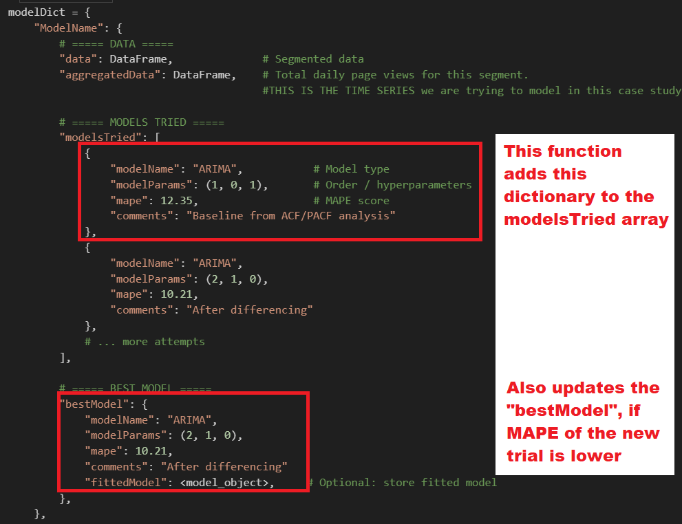

```python
def addModelAttempt(modelDict, segmentName, modelName, modelParams, mape, comments="", verbose=False):
    """
    Add a model attempt to the modelsTried list for a segment.

    Parameters:
    -----------
    verbose : bool
        If True, prints status message. Default False.
    """
    attempt = {
        "modelName": modelName,
        "modelParams": modelParams,
        "mape": round(mape, 4) if mape is not None else None,
        "comments":comments
    }

    modelDict[segmentName]["modelsTried"].append(attempt)

    # Auto-update best model if this is the best so far
    current_best = modelDict[segmentName]["bestModel"]
    is_new_best = False

    if mape is not None:
        if current_best is None or mape < current_best["mape"]:
            modelDict[segmentName]["bestModel"] = {
                "modelName": modelName,
                "modelParams": modelParams,
                "mape": round(mape, 4),
            }
            is_new_best = True

    # Only print if verbose
    if verbose:
        if mape is not None:
            if is_new_best:
                print(f"✅ [{segmentName}] New best: {modelName}{modelParams} | MAPE: {mape:.4f}%")
            else:
                print(f"📝 [{segmentName}] Added: {modelName}{modelParams} | MAPE: {mape:.4f}%")
        else:
            print(f"⚠️ [{segmentName}] Added: {modelName}{modelParams} | MAPE: None | {modelName}")

    return is_new_best
```

### `getModelHistory()`

```python
def getModelHistory(modelDict, segmentName):
    """
    Get all model attempts for a segment as a DataFrame.
    """
    import pandas as pd
    attempts = modelDict[segmentName]["modelsTried"]
    if not attempts:
        print(f"No models tried yet for {segmentName}")
        return None
    return pd.DataFrame(attempts)
```

### `getAllBestModels()`

```python
def getAllBestModels(modelDict):
    """
    Get best models for all segments as a DataFrame.
    """
    import pandas as pd
    results = []
    for name, config in modelDict.items():
        best = config["bestModel"]
        results.append({
            "Segment": name,
            "BestModel": best["modelName"] if best else None,
            "Params": best["modelParams"] if best else None,
            "MAPE": best["mape"] if best else None,
            "Comments": best["comments"] if best else None,
        })
    return pd.DataFrame(results)
```

### `getAttemptsSummaryTable()`

Returns a pandas datafame containing data of all experiments

```python
def getAttemptsSummaryTable(modelDict):
    """
    Get summary of all attempts across all segments.
    """
    import pandas as pd
    rows = []
    for segmentName, config in modelDict.items():
        for attempt in config["modelsTried"]:
            rows.append({
                "Segment": segmentName,
                "Model": attempt["modelName"],
                "Params": attempt["modelParams"],
                "MAPE": attempt["mape"],
                "Comments": attempt["comments"],
            })
    return pd.DataFrame(rows)

summary = getAttemptsSummaryTable(modelDict)
summary
```

### `printModelDictSummary()`

**Purpose:** Displays a summary of all data segments and validates data integrity.

**What it does:**

- Prints a markdown-formatted table showing all segments
- Displays row counts for each segment
- Shows model and MAPE values (if trained)
- Calculates total rows across all segments
- Compares against original dataframe to ensure no data loss

**Output Includes:**

- Summary table of all models
- Total row count
- Validation check against `df_with_extra_columns`
- Match/mismatch indicator

**Why it's useful:**

- Ensures data segmentation is complete
- Verifies no rows were lost or duplicated
- Provides quick overview of data distribution across segments

```python
def printModelDictSummary():
    """
    Prints summary of modelDict with new structure:
    - data, modelsTried, bestModel
    """
    totalRows = 0

    # Header
    print("## Model Dictionary Summary\n")
    print("| Model Name | Data Rows | # Attempts | Best Model | Best Params | Best MAPE |")
    print("|------------|-----------|------------|------------|-------------|-----------|")

    # Data rows
    for modelName, modelInfo in modelDict.items():
        rowCount = len(modelInfo['data']) if modelInfo['data'] is not None else 0
        totalRows += rowCount

        numAttempts = len(modelInfo['modelsTried'])

        if modelInfo['bestModel'] is not None:
            bestModelName = modelInfo['bestModel']['modelName']
            bestParams = modelInfo['bestModel']['modelParams']
            bestMape = f"{modelInfo['bestModel']['mape']:.4f}%" if modelInfo['bestModel']['mape'] is not None else 'None'
        else:
            bestModelName = 'None'
            bestParams = '-'
            bestMape = '-'

        print(f"| {modelName} | {rowCount} | {numAttempts} | {bestModelName} | {bestParams} | {bestMape} |")

    # Total row
    totalAttempts = sum(len(m['modelsTried']) for m in modelDict.values())
    print(f"| **TOTAL** | **{totalRows}** | **{totalAttempts}** | - | - | - |")

    # Validation
    originalRows = len(df_with_extra_columns)

    print("\n## Validation\n")
    print("| Metric | Count |")
    print("|--------|-------|")
    print(f"| Total rows across models | {totalRows} |")
    print(f"| Original dataframe rows | {originalRows} |")
    print(f"| Difference | {abs(totalRows - originalRows)} |")

    if totalRows == originalRows:
        print("\n✅ **MATCH:** Total rows equals original dataframe!")
    else:
        print(f"\n❌ **MISMATCH:** Difference of {abs(totalRows - originalRows)} rows")
```

### `printModelDictSummaryDETAILED()`

Generates a beautiful markdown summary of results in the modelDict

```python
def printModelDictSummaryDETAILED(showAttempts=False):
    """
    Prints summary of modelDict.

    Parameters:
    -----------
    showAttempts : bool
        If True, shows all attempts for each model
    """
    totalRows = 0

    # Header
    print("**Model Dictionary Summary** \n")
    print("| Model Name | Data Rows | # Attempts | Best Model | Best Params | Best MAPE |")
    print("|------------|-----------|------------|------------|-------------|-----------|")

    # Data rows
    for modelName, modelInfo in modelDict.items():
        rowCount = len(modelInfo['data']) if modelInfo['data'] is not None else 0
        totalRows += rowCount

        numAttempts = len(modelInfo['modelsTried'])

        if modelInfo['bestModel'] is not None:
            bestModelName = modelInfo['bestModel']['modelName']
            bestParams = modelInfo['bestModel']['modelParams']
            bestMape = f"{modelInfo['bestModel']['mape']:.4f}%" if modelInfo['bestModel']['mape'] is not None else 'None'

        else:
            bestModelName = 'None'
            bestParams = '-'
            bestMape = '-'


        print(f"| {modelName} | {rowCount} | {numAttempts} | {bestModelName} | {bestParams} | {bestMape}")

        # Show all attempts if requested
        if showAttempts and numAttempts > 0:
            print(f"|   ↳ Attempts: | | | | | |")
            for j, attempt in enumerate(modelInfo['modelsTried'], 1):
                mape_str = f"{100*attempt['mape']:.1f}%" if attempt['mape'] is not None else 'Error'
                comment = attempt['comments'][:30] + '...' if len(attempt['comments']) > 30 else attempt['comments']
                print(f"|   {j}. {attempt['modelName']}{attempt['modelParams']} | | | | {mape_str} | {comment} |")

    # Total row
    totalAttempts = sum(len(m['modelsTried']) for m in modelDict.values())
    print(f"| **TOTAL** | **{totalRows}** | **{totalAttempts}** | - | - | - |")

    # Validation
    originalRows = len(df_with_extra_columns)

    print("\n**Validation**\n")
    print("| Metric | Count |")
    print("|--------|-------|")
    print(f"| Total rows across models | {totalRows} |")
    print(f"| Original dataframe rows | {originalRows} |")
    print(f"| Difference | {abs(totalRows - originalRows)} |")

    if totalRows == originalRows:
        print("\n✅ **MATCH:** Total rows equals original dataframe!")
    else:
        print(f"\n❌ **MISMATCH:** Difference of {abs(totalRows - originalRows)} rows")

    # Best MAPE Summary
    print("\n**Best MAPE Ranking**\n")
    print("| Rank | Segment Name | Best MAPE |Source")
    print("|------|------------|-----------|------|")

    ranked = sorted(
        [(name, info['bestModel']['mape'], info['bestModel']['modelName'],info['bestModel']['modelParams'] ) for name, info in modelDict.items() if info['bestModel'] is not None],
        key=lambda x: x[1]
    )

    for rank, (name, mape,modelName, modelParams) in enumerate(ranked, 1):
        print(f"| {rank} | {name} | {100*mape:.1f}% |{modelName}{modelParams}")

    if not ranked:
        print("| - | No models fitted yet | - |")

# Usage
# printModelDictSummary()              # Basic summary
# printModelDictSummary(showAttempts=True)  # With all attempts
```

# 3.0 Explore Data Characteristics

## 3.1 Univariate Analysis (Analysis of one attribute at a time.)

#### univariate_ordinal_analysis

Creating a helper function to plot multiple graphs in one figure for ordinal data

```python
import pandas as pd
import matplotlib.pyplot as plt

def univariate_ordinal_analysis(series, column_name, order=None, plotCount=None ):
    """
    Print summary statistics and plot distribution for an ordinal categorical Series.

    Parameters:
        series : pd.Series
            The ordinal categorical column.
        order : list (optional)
            Ordered list of categories (if not the Series' CategoricalDtype).
        plotCount:Pass none if both graphs wanted, 1 if only first one wanted
            in some cases, the second graph is not that useful
            Maybe in future if i find a better graph I will put it.
    """

    # Ensure categorical with order
    if not pd.api.types.is_categorical_dtype(series):
        series = series.astype("category")
    if order is not None:
        series = series.cat.set_categories(order, ordered=True)

    # Value counts in order
    counts = series.value_counts().reindex(series.cat.categories)
    perc = counts / counts.sum() * 100



    # Plot
    ax=[]
    if plotCount==1:
        fig, ax1 = plt.subplots(figsize=(10, 4))
        ax.append(ax1)
    else:
        fig, ax = plt.subplots(1, 2, figsize=(10, 4))


    # Bar plot (counts)
    bars = counts.plot(kind="bar", ax=ax[0], color="skyblue")
    ax[0].set_title(f"{column_name} Counts by Category")
    ax[0].set_ylabel("Count")

    # --- Annotate each bar with count and percentage ---
    total = sum(p.get_height() for p in ax[0].patches)
    for patch in ax[0].patches:
        height = patch.get_height()
        if height > 0:
            pct = height / total * 100
            ax[0].text(
                patch.get_x() + patch.get_width() / 2,  # center of bar
                height + (total * 0.005),               # position slightly above bar
                f"{int(height)}\n({pct:.1f}%)",         # count + % in next line
                ha='center', va='bottom', fontsize=8, color='black'
            )
    if(len(ax)>1): #draw only if plotCount is not 1
        # Cumulative percentage
        perc.cumsum().plot(marker="o", ax=ax[1], color="red")
        ax[1].set_title("Cumulative % by Category")
        ax[1].set_ylabel("Cumulative %")
        ax[1].set_ylim(0, 100)
        ax[1].grid(True, linestyle="--", alpha=0.5)

    plt.tight_layout()
    plt.show()
        # Print summary
    print(f"\n📊 Summary Statistics for {column_name}")
    print("="*50)
    print(f"Mode   : {series.mode().iloc[0]}")
    print(f"Median : {series.sort_values().iloc[len(series)//2]}")
    # print("\nValue Counts (%):")
    # df_analysis=pd.DataFrame({"Count": counts, "Percent": perc.round(2)})
    # print(df_analysis)
    # df_analysis.sort_values(by="Percent", ascending=False, inplace=True)
    # print("Breakup of grades-"+", ".join([f"{idx} ({row['Percent']}%)" for idx, row in df_analysis.iterrows()]))
```

### page_title

```python
df_analysis = df.groupby("page_title").language.count()
print(f"We have {len(df_analysis)} unique pages across {len(df)} rows, as one page can be in different languages")
```

```
We have 48874 unique pages across 144411 rows, as one page can be in different languages
```

We have 48874 unique pages across 144411 rows, as one page can be in different languages Page names are not only in English alphabet. For ex, Russian pages are in their alphabet.

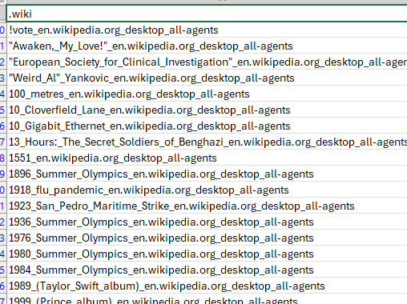

- The page name has useful info.
- We use a small embedding model to help understand the category. Maybe we can cluster pages.
- We want to identify some major clusters so that when user gives a page, we can find its category and use that sarimax model (so basically looking for another dimension for segmenting data)
- This study was done separately and **sentence-transformers/paraphrase-multilingual-MiniLM-L12-v2** was used to embed (as the data contains multiple languages)
- After that we ran HDBScan on it to auto identify clusters.
- Following clusters were identified

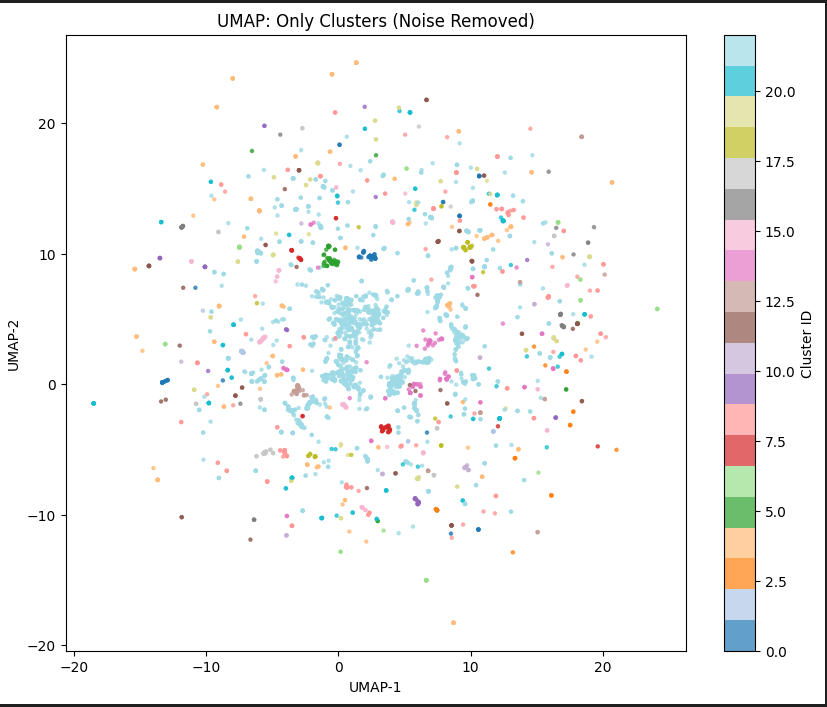

- Not incorporated that study in this submission due to time constraints.
- Next step is to use a LLM to identify titles for these clusters by passing it some of the pages in these clusters and asking it to give a nice representative cluster name..
- This can be done in future.

We have 48874 unique pages across 144411 rows, as one page can be in different languages

### access_type

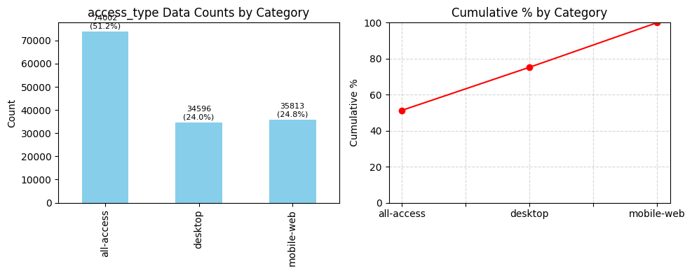

```
📊 Summary Statistics for access_type Data
==================================================
Mode   : all-access
Median : all-access
```

```python
col = 'access_type'

univariate_ordinal_analysis(df[col], f"{col} Data")
```

We have three access_types - all-access(51%), desktop(24%) and mobile(25%)

### access_origin

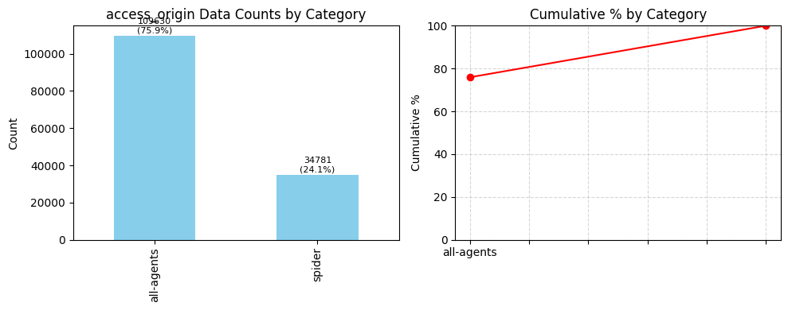

```
📊 Summary Statistics for access_origin Data
==================================================
Mode   : all-agents
Median : all-agents
```

```python
col = 'access_origin'

univariate_ordinal_analysis(df[col], f"{col} Data")
```

In terms of origin of request, 24% originate as spider queries, while rest are all-agents

### language

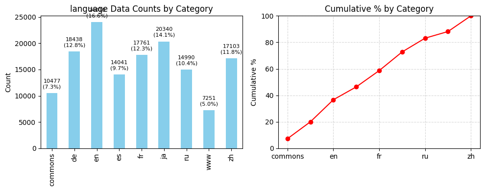

```
📊 Summary Statistics for language Data
==================================================
Mode   : en
Median : fr
```

```python
col = 'language'

univariate_ordinal_analysis(df[col], f"{col} Data")
```

```python
df.groupby(col).size()
```

```
language
commons    10477
de         18438
en         24010
es         14041
fr         17761
ja         20340
ru         14990
www         7251
zh         17103
dtype: int64
```

Here is the count of pages wrt language. See explanation of commons further in the note.

commons 10477

de 18438

en 24010

es 14041

fr 17761

ja 20340

ru 14990

www 7251

zh 17103

On Wikipedia (and Wikimedia projects in general), **“commons” refers to *Wikimedia Commons***.

**What is Wikimedia Commons?**

**Wikimedia Commons** is a **central media repository** for all Wikimedia projects. It stores **images, audio, video, and other media files** that are **free to use**.

👉 Website: commons.wikimedia.org

**What do those labels mean?**

When you see file links like:

- **en** → English Wikipedia
- **fr** → French Wikipedia
- **de** → German Wikipedia
- **commons** → Wikimedia Commons

they indicate **where the file is hosted**.

**Why is “commons” special?**

Files on **Wikimedia Commons**:

- Can be used on **all language Wikipedias** (en, fr, de, etc.)
- Don’t need to be uploaded separately for each language
- Must have **free licenses** (e.g., CC BY, CC BY-SA, public domain)

Files uploaded to **en/fr/de Wikipedia**:

- Are usually **local uploads**
- Often used when licensing doesn’t allow global reuse (e.g., fair use)
- Can only be used on that specific Wikipedia

**Summary**

- **commons = shared by everyone**
- **en/fr/de = local to that language**

### domain

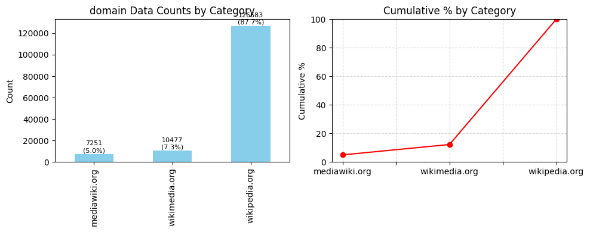

```
📊 Summary Statistics for domain Data
==================================================
Mode   : wikipedia.org
Median : wikipedia.org
```

```python
col = 'domain'

univariate_ordinal_analysis(df[col], f"{col} Data")
```

We have pages hosted across three domains - wikipedia.org(88%), wikimedia.org (7%) and mediawiki.org(5%)

**What is wikipedia, wikimedia and mediawiki**

These three are related, but they are **not the same thing**. Think of them as **content → organization → software**.

**1️⃣ Wikipedia**

**What it is:** 📘 **A free online encyclopedia**

- Website where people read and write articles (e.g., *Photosynthesis*, *India*, *Albert Einstein*).
- Content is written and edited by volunteers around the world.
- Anyone can read it; most pages can be edited by anyone.
- Articles aim to be **neutral**, **verifiable**, and **well-sourced**.

👉 Example:

- You search “Electrolysis” → you are using **Wikipedia**

🌐 Website: wikipedia.org

**2️⃣ Wikimedia**

**What it is:** 🏛️ **A non-profit organization**

- Full name: **Wikimedia Foundation**
- Owns and operates Wikipedia **and many other projects**.
- Provides servers, legal support, and funding.
- Does **not** write articles itself.

**Projects run by Wikimedia:**

- **Wikipedia** – encyclopedia
- **Wikimedia Commons** – images, videos, audio
- **Wiktionary** – dictionary
- **Wikibooks** – textbooks
- **Wikinews** – news
- **Wikidata** – structured data

👉 Example:

- The reason Wikipedia is free and has no ads → **Wikimedia Foundation**

🌐 Website: wikimediafoundation.org

**3️⃣ MediaWiki**

**What it is:** 💻 **Software**

- The **wiki software** that runs Wikipedia.
- Written mainly in PHP.
- Open-source (anyone can download and use it).
- Handles:
  - Editing pages
  - Version history
  - User accounts
  - Links between pages

👉 Example:

- Wikipedia runs on **MediaWiki**
- You can install MediaWiki and create your **own wiki**

For this case study perspective, files that are mentioned under mediawiki look like this

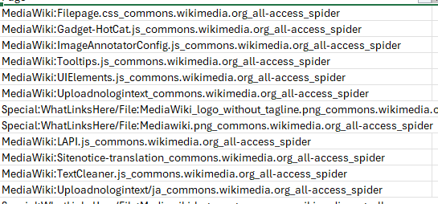

From the screenshot, we can infer this

- They are wiki system pages stored in the MediaWiki database.
- **Understanding MediaWiki: namespace**
  - It stores site-wide system messages and resources, such as:
    - CSS `MediaWiki:Filepage.css` which Controls styling of file pages
    - JavaScript `MediaWiki:Gadget-HotCat.js` Used for: UI behavior, Upload dialogs, Tooltips, Gadgets (optional user tools)
    - Text / i18n `MediaWiki:UploadDialogtext` Used for: Messages,Translations, Notices. 👉 These are stored as wiki pages in the database

🌐 Website: mediawiki.org

🔁 Simple analogy

Think of a **school**:

| Real World | Wiki World |
| --- | --- |
| Textbook | **Wikipedia** |
| School management | **Wikimedia Foundation** |
| Blackboard & classroom system | **MediaWiki** |

**Case study-centric definition (based on what the URL/page name represents)**

**wikipedia.org**

👉 **Textual encyclopedic content**

- Articles written for reading
- Mostly text + references (images are embedded but not hosted here)
- Examples:
  - `Photosynthesis`
  - `World_War_II`
  - `Electrolysis`

**Rule of thumb:**

> If it’s **wikipedia**, it’s **article text and structured prose**

**wikimedia.org / commons.wikimedia.org**

👉 **Media assets (files) + media description pages**

- Images, diagrams, maps
- Audio files
- Video files
- File description & category pages

Examples

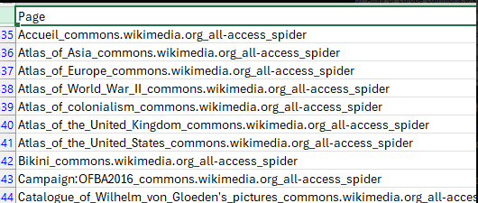

These are:

- Image collections
- Media catalogues
- Visual resources

**Rule of thumb:**

> If it’s **wikimedia / commons**, it’s **media files or pages describing media**

**mediawiki.org**

👉 **Software, UI, and site-behavior resources**

- JavaScript (gadgets, UI logic)
- CSS (styling)
- System messages
- API & extension documentation

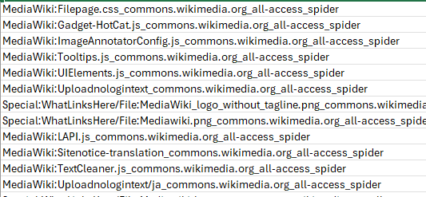

These are:

- Front-end behavior
- Interface logic
- Configuration artifacts

**Rule of thumb:**

> If it’s **mediawiki**, it’s **code, configuration, or software documentation**

## 3.2 Bivariate Analysis

### Helper function to plot all categories

```python
#Quickly plot sample data based on colName
def plotSamplesFrom(colName, sampleSize=15, campaign=False, **kwargs):
    # Iterate over all unique values in colName
    for val in df[colName].unique():
        # Select sampleSize random rows based on colName and each unique value
        rows, title = search_data(sampleSize, colName1=colName, val1=val)
        plot_data_staggered(rows, title, campaign=campaign, **kwargs)
```

### ClickCount and access_type

```
search_data():Searched random 15 rows where access_type == all-access
extractRowTransposeColumn():Transposing ALL rows from given dataframe that has 15 rows
```

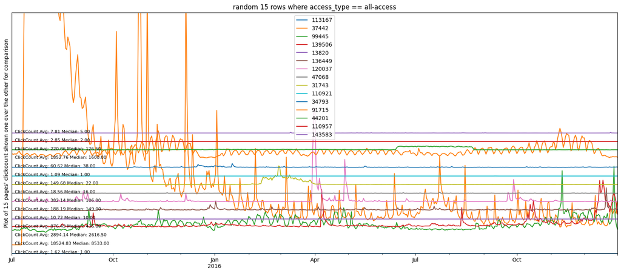

```
search_data():Searched random 15 rows where access_type == desktop
extractRowTransposeColumn():Transposing ALL rows from given dataframe that has 15 rows
```

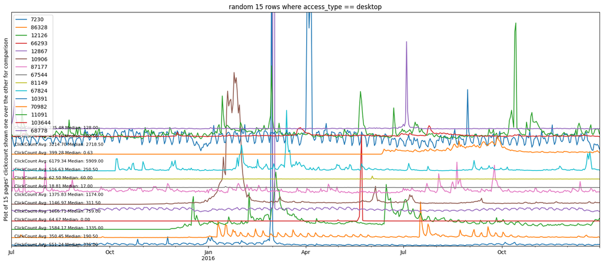

```
search_data():Searched random 15 rows where access_type == mobile-web
extractRowTransposeColumn():Transposing ALL rows from given dataframe that has 15 rows
```

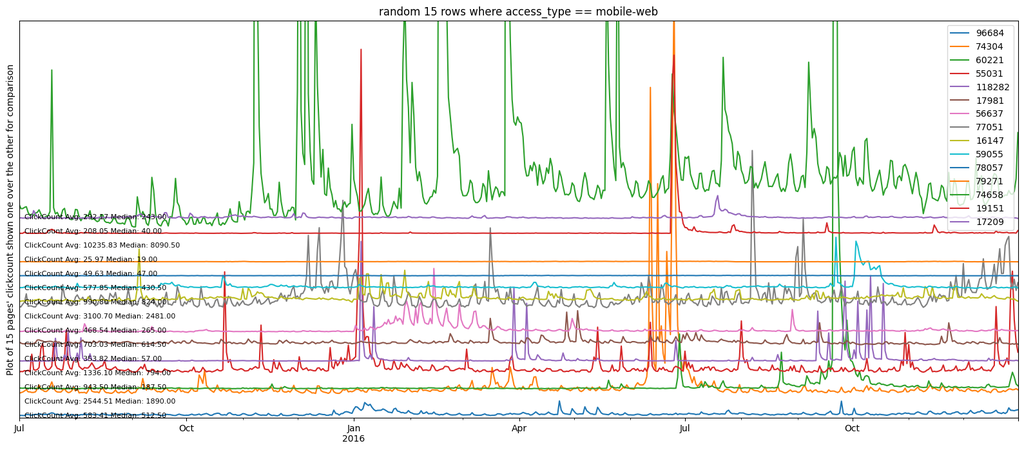

```python
plotSamplesFrom('access_type', campaign=False)
```

Data across pages is NOT dependent on access_type as we can see that for same access type, randomly selected rows dont have similar pattern

### ClickCount and access_origin

```
search_data():Searched random 15 rows where access_origin == spider
extractRowTransposeColumn():Transposing ALL rows from given dataframe that has 15 rows
```

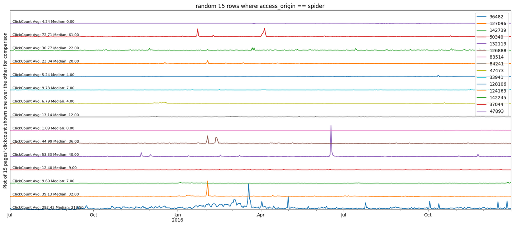

```
search_data():Searched random 15 rows where access_origin == all-agents
extractRowTransposeColumn():Transposing ALL rows from given dataframe that has 15 rows
```

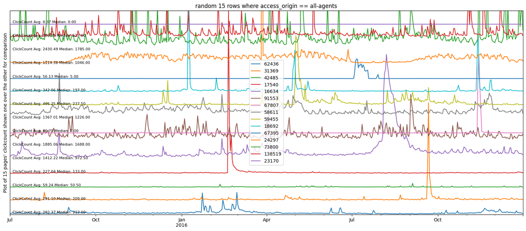

```python
plotSamplesFrom('access_origin',ylim=30000)
```

Click Count across pages **IS** dependent on access_origin as we can clearly see a difference.

- In spider, the graph is having almost no seasonality or variation except the occasional spikes
- In all_agents, data is much more varying across time

### ClickCount and language

```
search_data():Searched random 15 rows where language == zh
extractRowTransposeColumn():Transposing ALL rows from given dataframe that has 15 rows
```

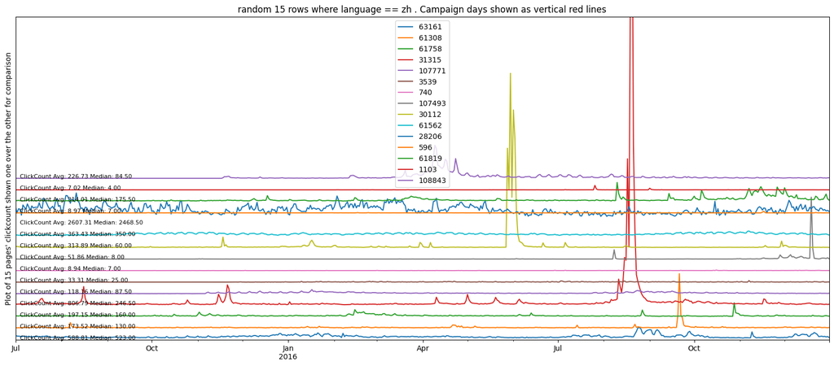

```
search_data():Searched random 15 rows where language == fr
extractRowTransposeColumn():Transposing ALL rows from given dataframe that has 15 rows
```

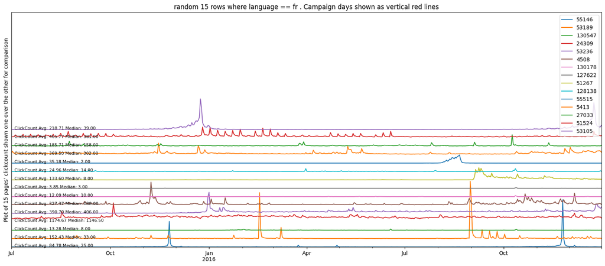

```
search_data():Searched random 15 rows where language == en
extractRowTransposeColumn():Transposing ALL rows from given dataframe that has 15 rows
```

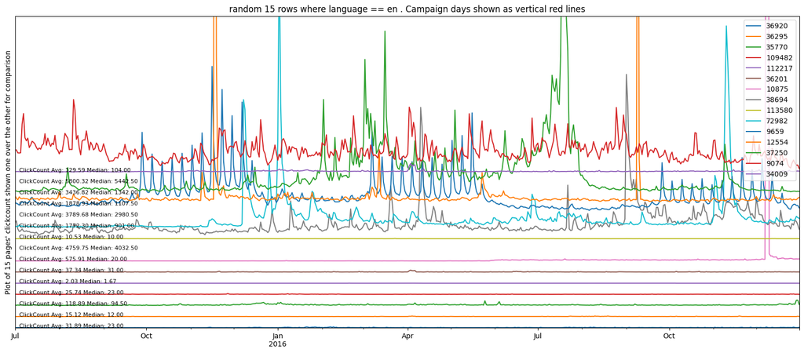

```
search_data():Searched random 15 rows where language == commons
extractRowTransposeColumn():Transposing ALL rows from given dataframe that has 15 rows
```

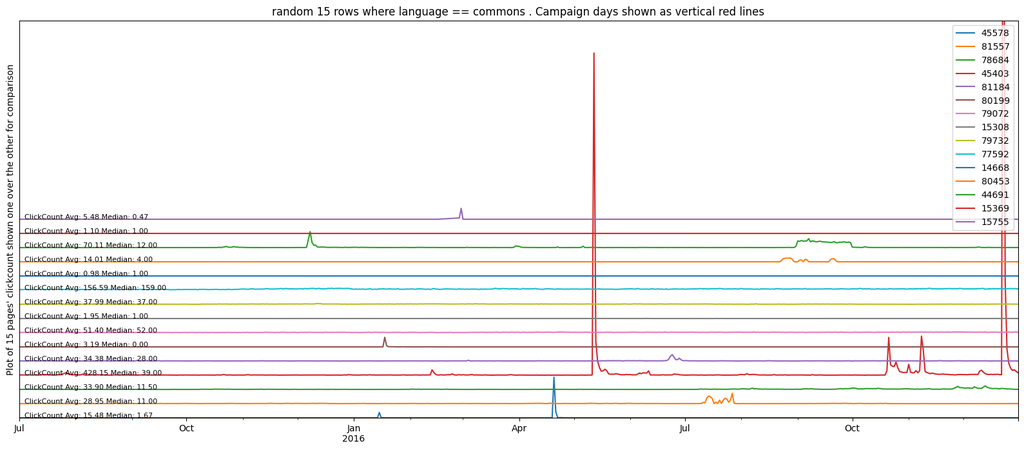

```
search_data():Searched random 15 rows where language == ru
extractRowTransposeColumn():Transposing ALL rows from given dataframe that has 15 rows
```

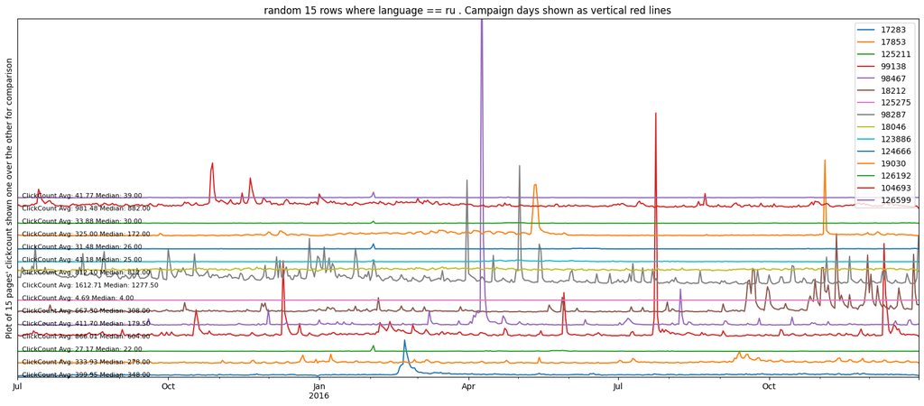

```
search_data():Searched random 15 rows where language == www
extractRowTransposeColumn():Transposing ALL rows from given dataframe that has 15 rows
```

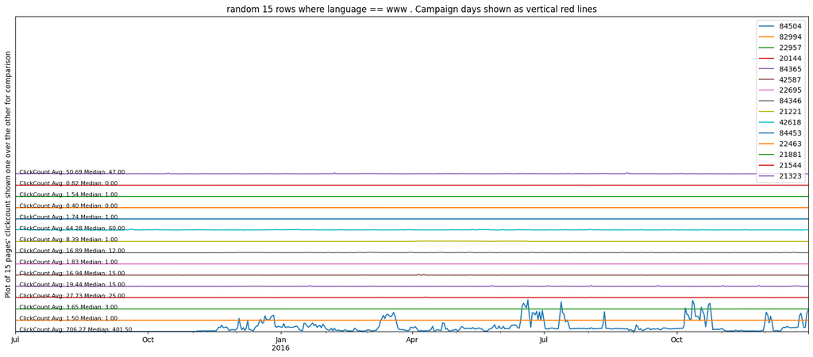

```
search_data():Searched random 15 rows where language == de
extractRowTransposeColumn():Transposing ALL rows from given dataframe that has 15 rows
```

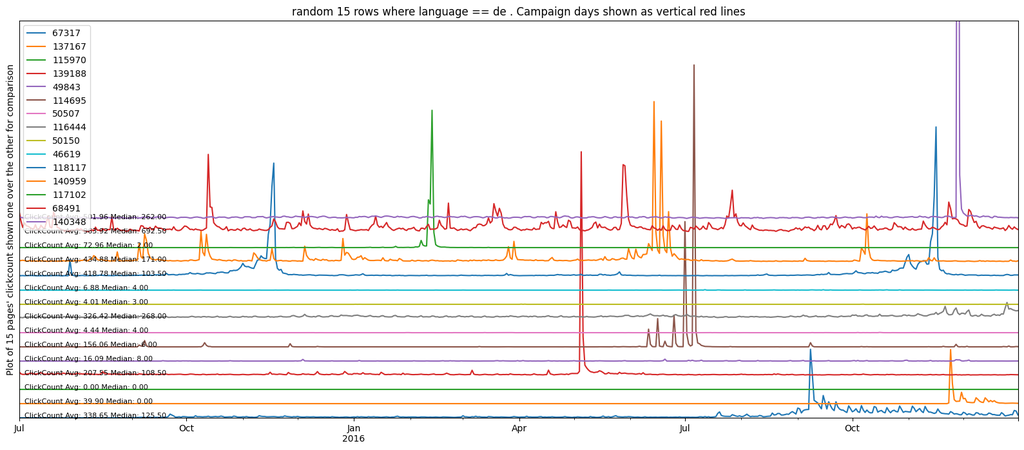

```
search_data():Searched random 15 rows where language == ja
extractRowTransposeColumn():Transposing ALL rows from given dataframe that has 15 rows
```

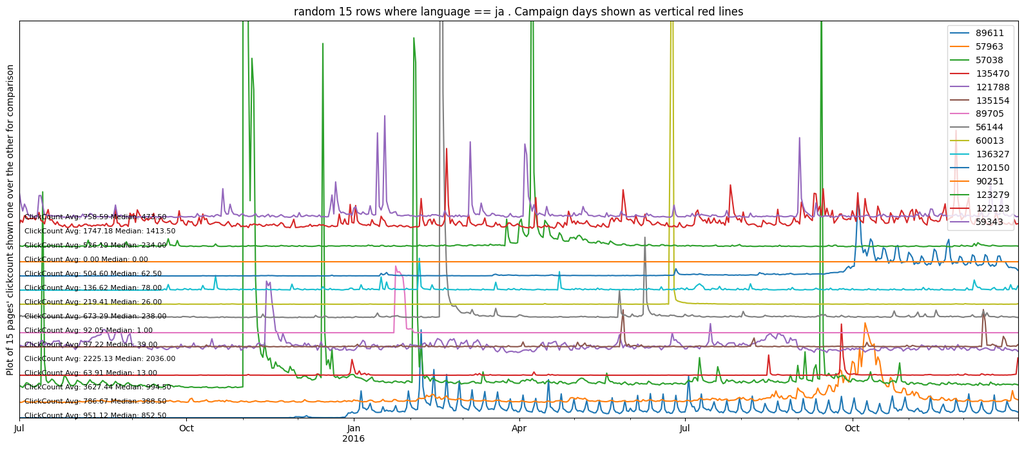

```
search_data():Searched random 15 rows where language == es
extractRowTransposeColumn():Transposing ALL rows from given dataframe that has 15 rows
```

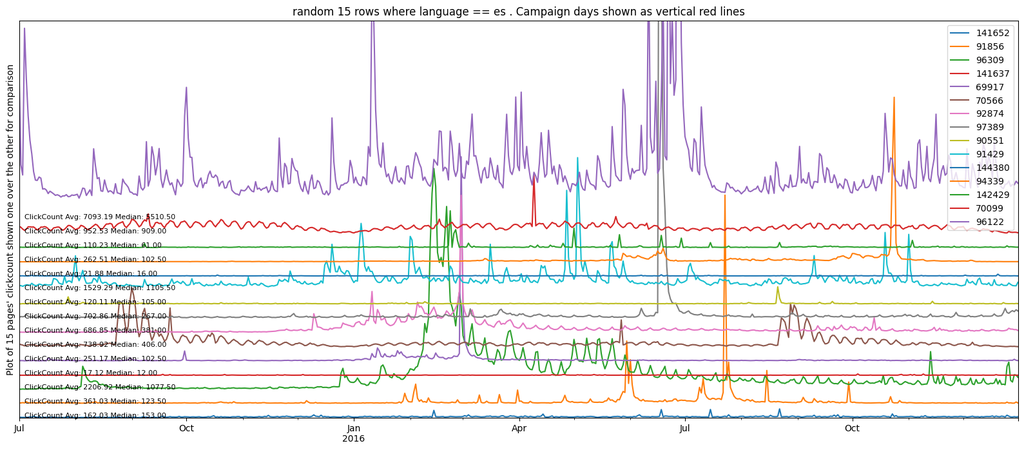

```python
plotSamplesFrom('language', campaign=True)
```

#### Do EN pages cluster differently from FR pages in level/variance/seasonality/autocorrelation (things SARIMAX cares about)?

The feature + label-permutation test is aimed at exactly that.

- Treat each page time series as an intact block (we never shuffle days within a page).
- Compute a set of time-series features per page (level, variability, tail behavior, autocorrelation, weekly seasonality, etc.).
- Do a permutation test that shuffles the language labels across pages and checks whether EN vs FR differ in those features.
- This directly tests: “Is language a meaningful segmentation variable?” (without requiring the unrealistic claim that all EN pages have the same distribution).

```python
import re
import numpy as np
import pandas as pd

def get_date_columns(df):

    # Find all columns like "2015-07-01"
    date_cols = [c for c in df.columns if re.fullmatch(r"\d{4}-\d{2}-\d{2}", str(c))]

    #ensure they are in chronological order (important so lags like 7 days make sense).
    date_cols = sorted(date_cols)

    if not date_cols:
        raise ValueError("No date columns found. Are your date columns named like YYYY-MM-DD?")

    # converts those column-name strings into actual datetime64 values
    dates = pd.to_datetime(date_cols)
    return date_cols, dates

# Purpose: compute autocorrelation at a specific lag.
# Lag 1: correlation between today and yesterday
# Lag 7: correlation between today and same weekday last week (weekly pattern)
def autocorr(x, lag):
    x = np.asarray(x, float)
    if len(x) <= lag + 2:
        return np.nan
    #align the series with itself shifted by lag.
    x0 = x[:-lag]
    x1 = x[lag:]

    #Check if  data are constant (std=0).
    if np.std(x0) == 0 or np.std(x1) == 0:
        return np.nan
    # Pearson correlation between the aligned vectors.
    return float(np.corrcoef(x0, x1)[0, 1])

# Our dataframe is wide: one row = one page; many columns are dates (counts), plus some metadata columns like language.
# The goal of this code block is to transform our wide table into a new table where:
    # each row = one page
    # each column = a summary feature of that page’s time series (mean, std, quantiles, autocorrelation, weekly seasonality, etc.)

# Purpose: take one page’s time series (one row of date columns) and convert it into numeric features.
def page_features_from_row(counts, dates):
    """
    counts: array-like length T (daily counts for a page)
    dates: DatetimeIndex length T
    """

    # a) Create a time-indexed series and drop missing
    # pairs each count with its date
    s = pd.Series(counts, index=dates).dropna()
    if len(s) < 60:   # require enough history
        return None

    # stabilize count scale
        # log1p(z) = log(1+z)
        # helps because page hits can be heavy-tailed (big spikes) and variance increases with level
        # makes features like mean/std more comparable across pages
    x = np.log1p(s.to_numpy())

    # Compute “distribution” features
        # mean / std / quantiles of x
        # "p_zero": fraction of days with exactly zero hits (important for sparse pages)
    feats = {
        # marginal-ish distribution features
        "mean": float(np.mean(x)),
        "std":  float(np.std(x, ddof=1)),
        "q10":  float(np.quantile(x, 0.10)),
        "q50":  float(np.quantile(x, 0.50)),
        "q90":  float(np.quantile(x, 0.90)),
        "p_zero": float(np.mean(s.to_numpy() == 0)),

        # dynamics (time dependence)
        "acf1": autocorr(x, 1),
        "acf7": autocorr(x, 7),
    }

    # weekday seasonality strength
    #If different weekdays have very different average traffic,
    # dow_means varies a lot → larger numerator → bigger weekday_strength.

    # If weekdays don’t matter, weekday means are similar → low numerator → small strength.
    ser = pd.Series(x, index=s.index)
    dow_means = ser.groupby(ser.index.dayofweek).mean()
    feats["weekday_strength"] = float(np.var(dow_means) / (np.var(ser) + 1e-12))

    return feats

# ---- build feature matrix from the wide df ----
date_cols, dates = get_date_columns(df)

langs = df["language"].to_numpy()
# extract just the date columns as a matrix:
Y = df[date_cols].to_numpy()  # shape (n_pages, T)

rows = []
lang_keep = []
for i in range(len(df)):
    feats = page_features_from_row(Y[i, :], dates)
    if feats is None:
        continue
    rows.append(feats)
    lang_keep.append(langs[i])

F = pd.DataFrame(rows).replace([np.inf, -np.inf], np.nan).dropna()
lang_keep = np.array(lang_keep)[F.index]  # align

# standardize features (so distance isn’t dominated by one feature) for distance computations
# This makes each feature roughly mean 0 and std 1 across pages.
# Without this, a feature on a larger numeric scale (say mean) could dominate the energy distance,
#  drowning out seasonality/autocorrelation features.
X = F.to_numpy()
X = (X - X.mean(axis=0)) / (X.std(axis=0) + 1e-12)

print(F.head())
print("Kept pages:", len(F), "Languages:", pd.Series(lang_keep).value_counts().to_dict())
```

```
       mean       std       q10       q50       q90    p_zero      acf1  \
0  2.872338  0.613641  2.197225  2.833213  3.666093  0.000000  0.238057
1  3.019816  0.621835  2.397895  2.890372  3.830792  0.000000  0.320428
2  1.499150  0.646674  0.693147  1.609438  2.079442  0.038182  0.304911
3  2.677635  0.590726  2.079442  2.639057  3.367296  0.000000  0.152513
4  0.883309  1.108791  0.000000  0.000000  2.397895  0.541818  0.818911

       acf7  weekday_strength
0  0.238220          0.010182
1  0.148605          0.005000
2  0.116656          0.003280
3  0.085106          0.006536
4  0.753200          0.001832
Kept pages: 144191 Languages: {'en': 23980, 'ja': 20328, 'de': 18399, 'fr': 17745, 'zh': 17079, 'ru': 14974, 'es': 14031, 'commons': 10464, 'www': 7191}
```

energy_stat_fast computes the energy-distance separation between two language groups using a precomputed pairwise distance matrix and indicator vectors, enabling thousands of label permutations without recomputing distances or allocating enormous intermediate arrays.

**Context: what statistic are we computing?** For two groups of pages (e.g., EN vs FR), each page is represented by a feature vector (mean, std, acf1, …). The **energy distance** between the two groups is:

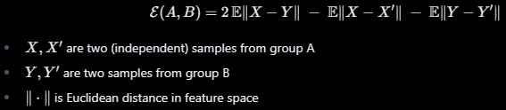

If A and B come from the same distribution (in feature space), this tends to be small; if they differ, it tends to be larger.

**Why `energy_stat_fast` is needed** A direct implementation often computes all pairwise distances between EN and FR by broadcasting, which can create a massive temporary array

Instead, we:

1. **Precompute one distance matrix** (D) of size (N\times N) for a subsample of pages, where:
   - (D_{ij} = |x_i - x_j|)
2. For each permutation, we only change group membership labels and recompute the statistic using **matrix-vector operations**—no expensive recomputation of distances, no 3D arrays.

That’s exactly what `energy_stat_fast` does.

**What `energy_stat_fast(D, mask_a)` computes**

**Inputs**

- `D`: an (N\times N) matrix of pairwise distances between all sampled pages.
- `mask_a`: boolean vector length (N). `True` means “this page is in group A” (e.g., EN).

Inside the function:

```
g = mask_a.astype(np.float32)   # indicator vector for group A (1 if in A else 0)
gb = 1.0 - g                    # indicator vector for group B
n = g.sum()                     # size of A
m = N - n                       # size of B
```

**Key trick: compute average distances via quadratic forms** Using the indicator vectors, these quantities can be computed:

- **Average distance between groups** (A–B):

Computed as:

```
d_ab = (g @ D @ gb) / (n * m)
```

- **Average distance within group A**:

Computed as:

```
d_aa = (g @ D @ g) / (n * n)
```

- **Average distance within group B**:

Computed as:

```
d_bb = (gb @ D @ gb) / (m * m)
```

Then the energy statistic is:

```
2*d_ab - d_aa - d_bb
```

**Why this is fast**

- `D` is computed **once**.
- Each permutation only changes `mask_a`, and the statistic is computed using a few dense linear algebra operations.
- No huge intermediate arrays; memory stays manageable.

**Note about including the diagonal** This implementation averages with denominators (n^2), (m^2) (so it includes (D_{ii}=0) terms). Since (D_{ii}=0), including them mainly changes the exact scaling slightly; importantly, it’s **consistent across permutations**, so the permutation p-value remains valid.

```python
import numpy as np
from sklearn.metrics import pairwise_distances

# Key idea:
# Keep each page’s time series intact (already done when you computed features from the full series).
# Test whether EN vs FR differ by shuffling language labels across pages.
# To make it computationally feasible, randomly sample e.g. 2000–5000 pages per language.

def energy_stat_fast(D, mask_a):
    """
    Energy statistic from a precomputed distance matrix D (N x N),
    where mask_a is a boolean vector for group A membership.
    Uses matrix-vector products (no huge submatrix copies).
    """
    g = mask_a.astype(np.float32)
    n = float(g.sum())
    m = float(len(g) - n)
    if n < 2 or m < 2:
        return np.nan

    gb = 1.0 - g

    # Mean distances (including diagonal; consistent across permutations)
    d_ab = (g @ D @ gb) / (n * m)
    d_aa = (g @ D @ g)  / (n * n)
    d_bb = (gb @ D @ gb) / (m * m)

    return float(2.0 * d_ab - d_aa - d_bb)

def perm_test_energy_subsample(X, labels, lang_a="en", lang_b="fr",
                               k_per_group=3000, n_perm=1000, seed=0):
    """
    X: feature matrix (n_pages, p)
    labels: language labels (n_pages,)
    Subsamples k_per_group from each language, precomputes distances once,
    then runs label permutations.
    """
    rng = np.random.default_rng(seed)
    labels = np.asarray(labels)

    ia = np.where(labels == lang_a)[0]
    ib = np.where(labels == lang_b)[0]
    if len(ia) == 0 or len(ib) == 0:
        raise ValueError("One of the languages has 0 pages.")

    ka = min(k_per_group, len(ia))
    kb = min(k_per_group, len(ib))

    sa = rng.choice(ia, size=ka, replace=False)
    sb = rng.choice(ib, size=kb, replace=False)

    idx = np.concatenate([sa, sb])
    Xs = X[idx].astype(np.float32, copy=False)
    labs = labels[idx]

    # Precompute distances once (N x N). With N=6000 float32 ~ 144MB.
    D = pairwise_distances(Xs, metric="euclidean", n_jobs=-1).astype(np.float32)

    mask_a = (labs == lang_a)
    obs = energy_stat_fast(D, mask_a)

    perm_stats = np.empty(n_perm, dtype=np.float32)
    for i in range(n_perm):
        perm_mask = rng.permutation(mask_a)
        perm_stats[i] = energy_stat_fast(D, perm_mask)

    pval = (1 + np.sum(perm_stats >= obs)) / (n_perm + 1)
    return obs, pval, perm_stats

# Example usage:
obs, pval, _ = perm_test_energy_subsample(
    X, lang_keep,
    lang_a="en", lang_b="fr",
    k_per_group=3000,
    n_perm=1000,
    seed=0
)
print("Energy statistic:", obs)
print("Permutation p-value:", pval)
```

```
Energy statistic: 0.2497506666666669
Permutation p-value: 0.000999000999000999
```

**How to interpret**

- pval < 0.05: EN vs FR pages differ systematically (in the chosen features) → language is likely a useful segmentation.
- pval >= 0.05: no clear evidence language separates them (by these features).

**Conclusion from this test**

- **EN vs FR pages are not drawn from the same distribution of time-series behavior** (as summarized by our features: mean/std/quantiles/zero-rate/autocorr/weekday strength).
- We can **reject the null** “English and French pages are similar (in these features)” because the permutation p-value is **~0.001**.

So **language is a statistically strong separator** in our data

**Implication for model creation**

- This **supports** using language as a segmentation criterion (EN behaves differently from FR in distribution/dynamics).
- We may consider creating separate models based on languages.

### ClickCount and domain

```
search_data():Searched random 15 rows where domain == wikipedia.org
extractRowTransposeColumn():Transposing ALL rows from given dataframe that has 15 rows
```

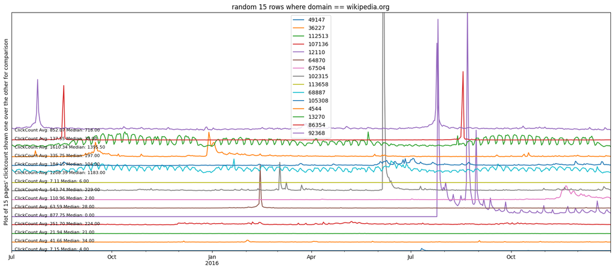

```
search_data():Searched random 15 rows where domain == wikimedia.org
extractRowTransposeColumn():Transposing ALL rows from given dataframe that has 15 rows
```

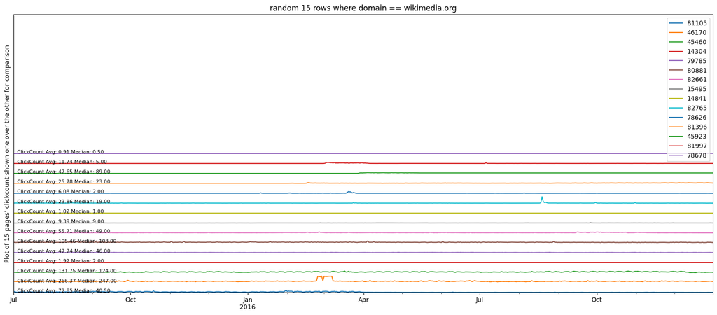

```
search_data():Searched random 15 rows where domain == mediawiki.org
extractRowTransposeColumn():Transposing ALL rows from given dataframe that has 15 rows
```

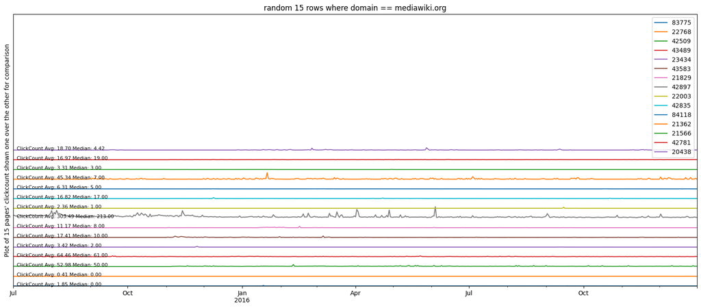

```python
plotSamplesFrom('domain')
```

Like language, domain too has a significant difference in distribution. It can be used as a criteria for segmenting and creating separate model based on domain.

#### annotate_bars

Helper function to add values on top of bars.

```python
#Helper function to add values on top of bars.
def annotate_bars(barplot,fmt='%.1f'):
    # --- Annotate the bars ---
    for container in barplot.containers:
        barplot.bar_label(
            container,
            fmt=fmt,       # Format as 1 decimal + %
            label_type='edge',  # Label outside bar; use 'center' to put inside
            fontsize=9,
            padding=2
        )
```

```python
from scipy.stats import chi2_contingency



def perform_chi_square_test(df, col1, col2, alpha=0.05,log="detailed", **kwargs):
    """
    Perform Chi-square test on two categorical columns from a DataFrame
    Also checks the Cramer's V value to establish if the association is of practical significance or only statistical.

    Parameters:
    df: pandas DataFrame
    col1: string, name of first categorical column
    col2: string, name of second categorical column
    alpha: float, significance level (default 0.05)

    Returns:
    dict with test results
    """
    li="<li>"
    # Create contingency table
    contingency_table = pd.crosstab(df[col1], df[col2])


    # Perform chi-square test
    Ho=f"{li}{col1} and {col2} are independent."
    Ha=f"{li}{col1} and {col2} are DEPENDENT"
    chi2_stat, p_value, dof, expected = chi2_contingency(contingency_table)

    # Compute effect size (Cramér's V)
    n = contingency_table.sum().sum()
    phi2 = chi2_stat / n
    r, k = contingency_table.shape
    cramers_v = (phi2 / min(k-1, r-1)) ** 0.5

    # p-value Interpretation
    if p_value < 0.05:
        relation = "Dependent (Significant)"
    else:
        relation = "Independent (Not significant)"


    # Cramer V Effect size Interpretation
    if cramers_v < 0.1:
        effectDesc = f"However, association is Negligible(CramersV={cramers_v:.2f})"
    elif cramers_v < 0.3:
        effectDesc = f"However, association is Weak(CramersV={cramers_v:.2f})"
    elif cramers_v < 0.5:
        effectDesc = f"And, association is Moderate(CramersV={cramers_v:.2f})"
    else:
        effectDesc = f"And, association is Strong(CramersV={cramers_v:.2f})"

    # Results
    results = {
        'chi2_statistic': chi2_stat,
        'p_value': p_value,
        'degrees_of_freedom': dof,
        'expected_frequencies': expected,
        'contingency_table': contingency_table,
        'significant': (p_value < alpha)
    }

    # Print results
    if("detailed" in log):
        print("Contingency Table:")
        print(contingency_table)
        print("\n")
        print(f"Chi-square Test Results:")
        print(f"Chi-square statistic: {chi2_stat:.4f}")
        print(f"p-value: {p_value:.4f}")
        print(f"Degrees of freedom: {dof}")
        print(f"Significant at α={alpha}: {'Yes' if results['significant'] else 'No'}")

    if results['significant']:
        if("detailed" in log):
            print(f"Reject Null Hypothesis. Alternate Hypothesis '{Ha}' is True, p-value:{results['p_value']}. {effectDesc}")
        else:
            print(f'{Ha}(p:{results['p_value']:.2f}), however {effectDesc}')
    else:
        if("detailed" in log):
            print(f"Fail to Reject Null Hypothesis. Null Hypothesis '{Ho}' is True, p-value:{results['p_value']}")
        else:
              print(f'{Ho}(p:{results['p_value']:.2f})')

    if("noplot" not in log):

        # We create two crosstabs
        crossNormalized12 = pd.crosstab(df[col1], df[col2], normalize='index') * 100
        crossNormalized21 = pd.crosstab(df[col2], df[col1], normalize='index') * 100

        # Create 1x3 subplot figure

        fig, axes = plt.subplots(1, 3, figsize= kwargs.get("figsize", (12, 5))) #pass figsize while calling

        colors = [
            "salmon", "skyblue",
            "lightgreen", "gold", "orchid", "coral", "khaki",
            "plum", "turquoise", "lightsteelblue", "tan", "lightpink",
            "mediumseagreen", "wheat", "lightsalmon", "aquamarine",
            "thistle", "palegoldenrod", "powderblue", "peru", "lightcyan",
            "violet", "darkseagreen", "peachpuff", "mistyrose"
        ]
        # determine how many categories you have
        num_categories = len(crossNormalized12.columns)

        # now slice the colors list accordingly
        color_list = colors[:num_categories]
        # --- First Plot: Col2 by Col1 ---
        bars = crossNormalized12.plot(kind='bar', stacked=False, ax=axes[0], color=color_list)
        axes[0].set_title(f"{col2} by {col1}")
        axes[0].set_ylabel(f"Percentage of {col2}")
        axes[0].set_xlabel(col1)
        axes[0].legend(title=col2)
        axes[0].tick_params(axis='x', rotation=0)
        annotate_bars(bars,'%.1f%%')

        # --- Second Plot: Col1 by Col2 ---
        bars = crossNormalized21.plot(kind='bar', stacked=False, ax=axes[1], color=color_list)
        axes[1].set_title(f"{col1} by {col2}")
        axes[1].set_ylabel(f"Percentage of {col1}")
        axes[1].set_xlabel(col2)
        axes[1].legend(title=col1)
        axes[1].tick_params(axis='x', rotation=0)
        annotate_bars(bars,'%.1f%%')

# pd.crosstab(df[col1], df[col2], normalize='index') * 100
        ct = pd.crosstab(df[col1], df[col2])
        sns.heatmap(ct, annot=True, fmt="d", cmap="Blues", ax=axes[2])
        plt.title(f"{col1} versus {col2}\nchi2={chi2_stat:.2f}, dof={dof}, p={p_value:.3g}, V={cramers_v:.3f}")
        plt.tight_layout()
        plt.show()

        plt.show()

    if("detailed" in log):
        print("="*50)
```

### access_origin and access_type

```
Contingency Table:
access_type    all-access  desktop  mobile-web
access_origin
all-agents          39221    34596       35813
spider              34781        0           0


Chi-square Test Results:
Chi-square statistic: 43591.0816
p-value: 0.0000
Degrees of freedom: 2
Significant at α=0.05: Yes
Reject Null Hypothesis. Alternate Hypothesis '<li>access_origin and access_type are DEPENDENT' is True, p-value:0.0. And, association is Strong(CramersV=0.55)
```

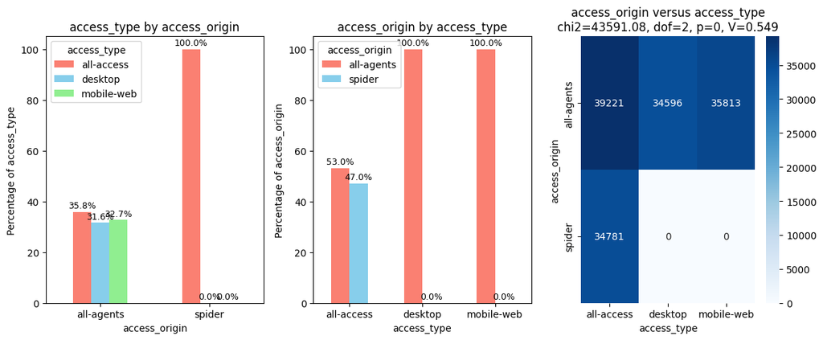

```python
# _ = chi2_categorical_pair(df, "access_origin", "access_type", plot=True, annot=True)
perform_chi_square_test(df, "access_origin", "access_type")
```

access_origin and access_type are DEPENDENT. p-value:0.0. And association is Strong(CramersV=0.55)

### language and access_origin

```
Contingency Table:
language       commons     de     en     es     fr     ja     ru   www     zh
access_origin
all-agents        7947  13874  19090  10511  13271  15342  11255  5516  12824
spider            2530   4564   4920   3530   4490   4998   3735  1735   4279


Chi-square Test Results:
Chi-square statistic: 213.1040
p-value: 0.0000
Degrees of freedom: 8
Significant at α=0.05: Yes
Reject Null Hypothesis. Alternate Hypothesis '<li>access_origin and language are DEPENDENT' is True, p-value:1.1012230133778792e-41. However, association is Negligible(CramersV=0.04)
```

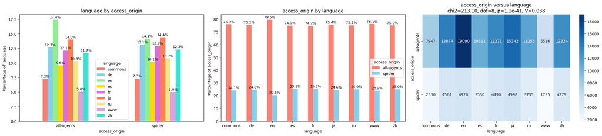

```python
perform_chi_square_test(df, "access_origin", "language",figsize=(22, 5))
```

access_origin and language are DEPENDENT. p-value:1.1012230133778792e-41. However, association is Negligible(CramersV=0.04)

### language and access_type

```
Contingency Table:
language     commons    de     en    es    fr    ja    ru   www    zh
access_type
all-access      5061  9127  14279  7060  8979  9995  7470  3473  8558
desktop         2526  4592   4961  3264  4039  5498  3796  1681  4239
mobile-web      2890  4719   4770  3717  4743  4847  3724  2097  4306


Chi-square Test Results:
Chi-square statistic: 995.5668
p-value: 0.0000
Degrees of freedom: 16
Significant at α=0.05: Yes
Reject Null Hypothesis. Alternate Hypothesis '<li>access_type and language are DEPENDENT' is True, p-value:9.96357592036832e-202. However, association is Negligible(CramersV=0.06)
```

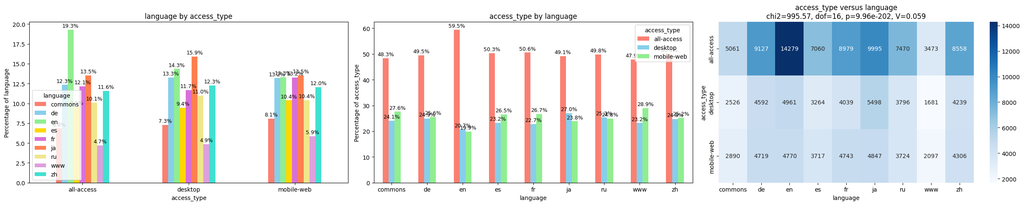

```python
perform_chi_square_test(df, "access_type", "language",figsize=(25, 5))
```

access_type and language are DEPENDENT' is True, p-value:9.96357592036832e-202. However, association is Negligible(CramersV=0.06)